# Project_2_Learner_FullCode

**Project 2**

```python
from google.colab import drive
drive.mount('/content/drive')
```

**AI for Research Proposal Automation**

## **Business Context**

**Metro State Research University (MSRU)** is a mid-sized public research university in the US Midwest, with roughly 450 active faculty investigators across STEM, health sciences, and social sciences. Like most research-intensive institutions, the institute's operating model depends heavily on indirect cost recovery from federal grants (NIH, NSF, DOE), so proposal volume and win rate directly translate to institutional funding health. The Office of Sponsored Programs manages 60-80 active federal and foundation Notices of Funding Opportunity (NOFOs) per year.

A **Notice of Funding Opportunity (NOFO)** is a formal announcement, typically from a federal agency such as NIH, NSF, or DOE, that a funding program is open, spelling out the research priorities, eligibility rules, deadlines, and award terms that applicants must follow to compete for a grant.

Proposal development draws on an internal corpus, spanning around 3,000 papers, technical reports and past proposal archives accumulated over the last 10 years, held across shared drives and departmental repositories in inconsistent formats.

In recent years, federal agencies have shortened several response windows, compressing the exact phase this project targets. Peer institutions have already started acted on this. For instance, Purdue announced an internal proposal-writing tool in March 2024, Colorado School of Mines ran a vendor beta across 2024 and 2025, WVU Health Sciences launched an in-house NOFO matcher in September 2025, and the University of Maryland School of Medicine had systems in production by August 2026.

## **Business Objective**

MSRU’s grants office and faculty spend an average of **110–140 hours per NOFO** reviewing the funding announcement, searching the internal research archive for relevant prior work, and drafting an initial concept note. The process is currently ad hoc, with no shared workflow connecting a new funding opportunity to the university’s research archive.

Internal tracking shows that only **40% of NOFOs released in a given quarter receive a submitted proposal**, largely because faculty run out of time to identify relevant prior work before the deadline window closes.

In 2023, MSRU piloted a **keyword-tagging system** to make research easier to retrieve. The initiative failed within two semesters because:

- tagging was inconsistent, with different terms used for the same topic;
- compliance dropped after the initial grants-office push; and
- keyword search could not reliably surface conceptually related work expressed using different terminology.

The core problem is therefore to create a scalable way to **interpret the intent of a new NOFO, semantically identify relevant prior research, synthesize evidence into viable research directions, and accelerate the creation of a reviewable first-draft concept note**.

### **Problem Statement**

MSRU aims to reduce the time and manual effort required to move from a newly released Notice of Funding Opportunity (NOFO) to a **reviewable, evidence-grounded first-draft concept note**. The institute aims to develop an AI-assisted, RAG-based workflow that helps faculty and the grants office move efficiently from a new Notice of Funding Opportunity (NOFO) to a reviewable first-draft concept note. This project focuses on an NIH call for proposals related to digital mental health solutions. With the funding deadline approaching, the institute is planning a pilot that uses generative AI to support the early stages of proposal development.

The proposed AI-assisted, RAG-based workflow solution should analyze the NOFO, identify its key research focus and requirements, retrieve relevant research from the existing research corpus using semantic retrieval, summarize the retrieved research, identify potential research gaps, generate candidate research directions, and use a selected direction to create a structured first-draft concept note.

The pilot is focused on digital health research, particularly research related to neuroscience and mental health interventions. It is intended to demonstrate how RAG and LLM-based workflows can assist researchers in identifying relevant institutional knowledge and developing evidence-grounded proposal ideas. The generated concept note is intended as a starting point for faculty review and refinement and should not be considered a final grant proposal or a substitute for scientific and expert review.

The broader developmental goals is to develop a generative AI-powered research proposal assistant that can:

- Support and streamline the early proposal development process by analyzing an NIH NOFO and generating a structured first-draft concept note.
- Identify relevant past research from the research corpus and synthesize its key findings, limitations, and open questions.
- Generate funding-aligned research ideas by combining the requirements and research priorities identified from the NOFO with evidence and gaps identified from the retrieved research.
- Generate a structured, evidence-grounded high-quality proposal based on the selected research direction, relevant research evidence, NOFO context satisfying both technical and scientific standards. This structured output will use provided proposal template as reference.
- Evaluate the generated concept note using an LLM-based rubric covering areas such as Innovation, Significance, Approach, and Investigator Expertise. It should be noted that the LLM based evaluation is advisory - the actual proposal requires a thorough review by the faculty and grants-office before being shared externally.

## **Solution Methodology**

The pilot focuses on digital health research, particularly research related to neuroscience and mental health interventions. The supplied research corpus contains papers and other research documents that serve as the knowledge base for the RAG workflow.

The objective is to create an AI-assisted research proposal workflow that can understand a funding opportunity, retrieve relevant institutional research, synthesize the retrieved evidence, suggest potential research directions, and generate a structured first-draft concept note for human review.

The steps in the workflow are as follows:

- Read and extract content from the NIH NOFO document.
- Analyze the NOFO to identify the central research topic.
- Load the supplied research papers and prepare them for semantic retrieval.
- Split research papers into smaller text chunks for retrieval.
- Generate embeddings for the research chunks using OpenAI embeddings.
- Store the embeddings and document chunks in a Chroma vector database.
- Retrieve research passages relevant to the NOFO topic using semantic search.
- Summarize the retrieved research and identify key contributions, limitations, and research gaps.
- Generate five potential research ideas aligned with the NOFO and retrieved research.
- Select a research idea for further development.
- Combine the selected idea, supporting research, NOFO, and proposal template to generate a first-draft concept note.
- Evaluate the generated concept note using an LLM-based rubric covering Innovation, Significance, Approach, and Investigator Expertise.
- Conduct human review of the generated concept note for accuracy, relevance, feasibility, and alignment with the NOFO.

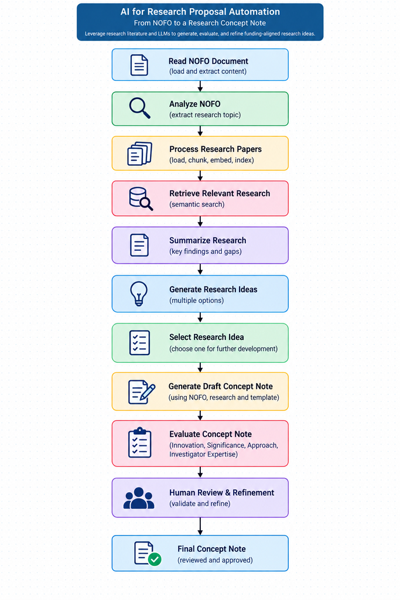

## **How to use this notebook**

This is the learner notebook for the project. Work through it top to bottom.

**What you have to do**

- Every `___` is a blank you must fill in. Some are a single argument, some are a whole prompt. Read the `# HINT:` and `# TASK:` comments directly above each blank.
- Cells marked *given to you as-is* are complete. You do not need to change them, but do read them, because later cells depend on the variables they create.
- Mark allocations are shown against each step heading and in the red notes.

**Rules**

- **Do not rename the given variables.**
- **Run the cells in order,** at least once through, before you go back and iterate. Several cells depend on state created earlier in the notebook.
- Place `config.json` and the dataset `Project_Files.zip` in `/content` before you start.

**Working on the prompts**

When a prompt is not producing what you expect, change the prompt rather than post-processing the output in Python. In particular:

- If the topic in Step 1 comes back as a sentence, your output constraint is too loose.
- If you receive a `ValueError`, your prompt did not pin the output format tightly enough.
- If you encounter a `JSONDecodeError`, your prompt is not returning pure JSON.

**Cost and runtime**

Step 2 embeds the full research corpus and then summarizes each shortlisted paper, and Step 4 sends full papers to the model. Avoid re-running those cells unnecessarily.

**Before you submit** ensure:

- Every `___` is replaced.
- The notebook runs top to bottom without errors on a fresh runtime.
- Cell outputs are saved in the submitted file.
- Steps 6 and 7 are filled in with your own review and observations.
- Finally, you've exported the notebook to HTML format for submission.

# **Step 1 - Setup [2 Marks]**

```python
# Install all required libraries and import everything used in the notebook

!uv pip install -q langchain-openai==0.3.27 \
                   langchain-core==0.3.68 \
                   langchain==0.3.26 \
                   langchain-community==0.3.20 \
                   langchain-chroma==0.2.4 \
                   pypdf==5.4.0 \
                   chromadb==1.5.9 \
                   tiktoken==0.14.0 \
                   markdown-pdf==1.7
```

```python
# Standard library
import json
import os
import re
import zipfile
from collections import defaultdict

# Display / notebook utilities
from IPython.display import Markdown, display

# LangChain + OpenAI
from langchain_openai import ChatOpenAI, OpenAIEmbeddings
from langchain_community.document_loaders import PyPDFLoader, PyPDFDirectoryLoader
from langchain_chroma import Chroma
from langchain_text_splitters import RecursiveCharacterTextSplitter

# Tokenization and PDF export
import tiktoken
from markdown_pdf import MarkdownPdf, Section
```

```python
import logging
logging.getLogger("pypdf").setLevel(logging.ERROR)
```

```python
# Unzip the Project files zip file
!unzip -o -q "/content/Project_Files.zip"
```

## Loading the Config file [1 Mark]

**Note:** *1 mark for Loading the Config file details.*

```python
import json
import os

# Load the JSON file and extract values
file_name = '/content/config.json'
with open(file_name, 'r') as file:
    config = json.load(file)
    # HINT: `config` is a dictionary loaded from config.json. Read the API key and the
    #       API base URL out of it and set them as environment variables, so that
    #       ChatOpenAI and OpenAIEmbeddings pick them up automatically without you
    #       having to pass credentials anywhere else in the notebook.
    #       The two keys in config.json are "API_KEY" and "OPENAI_API_BASE".

    os.environ['OPENAI_API_KEY'] = config['API_KEY']    # Loading the API Key
    os.environ["OPENAI_BASE_URL"] = config['OPENAI_API_BASE']   # Loading the API Base Url
```

## Defining the LLM

**Note:** *1 mark for the LLM Configuration.*

```python
MODEL = "gpt-5.6-luna"
```

```python
# Define the Model
# HINT: use the LangChain chat-model class imported in the setup cell, pass the MODEL
#       constant defined above so that your graded run
#       is reproducible rather than varying between executions.

llm = ChatOpenAI(model = MODEL)

## Smoke test the model and check if your configuration works.
## This is also the call pattern you will use everywhere else in the notebook:
## pass a prompt string in, and read the generated text off the returned message object.

llm.invoke("What is the capital of France?").content
```

```
'The capital of France is Paris.'
```

# **Step 2: Topic Extraction - [4 Marks]**

> **Read the NOFO document and identify the central topic or subject area for which funding is being provided.**

**Note:** *1 mark for correctly load and extract text from the NOFO. 2 marks for Writing an effective prompt for identifying the central funding topic. 1 mark for successfully generate the expected topic output.*

## Load and extract text from NOFO [1 Mark]

```python
# Reading the NOFO Document
# The NOFO (Notice of Funding Opportunity) is the funding announcement
# the single input that drives the whole run: the topic in Step 1, the retrieval
# query in Step 2, the alignment requirements in Step 3, and the evaluation
# context in Step 5 all come from this one document.

pdf_file = "/content/Project Files/NOFO.pdf"

# HINT: Use the single-file PDF loader from the setup imports (not the directory one),
#       then call its load() method. It returns a list with one Document per page.

pdf_loader = PyPDFLoader(pdf_file)
NOFO_pdf = pdf_loader.load()

# Convert loaded pages into clean text for downstream prompts
# The prompts need one continuous string, not a list of pages, so the pages are
# joined with a blank line between them to preserve the page boundaries visually.

NOFO_text = "\n\n".join(doc.page_content for doc in NOFO_pdf)
```

## Write an effective prompt for identifying the topic [2 Mark]

**TASK:** Write an LLM prompt that extracts the topic for which funding is being provided from the NOFO document, and instructs the model to respond with only the topic name.

```python
# TASK: Write the prompt that extracts the funding topic from the NOFO.
#
# Your prompt should:
#   1. Set a clear role for the model, for example an expert research funding analyst.
#   2. Ask for the single central research topic or subject area the NOFO funds.
#   3. Constrain the output tightly: a concise phrase of roughly 2-6 words. Not a
#      sentence, not an explanation, not the agency name, not a project title, not a list.
#   4. Tell the model to use the NOFO's own wording where it clearly names the topic.
#   5. Forbid inventing a topic that is not stated in the NOFO.
#
# Everything downstream depends on this one string, so keep it narrow. A vague topic
# produces a vague retrieval query in Step 2, and off-topic papers in Step 3.
#
# The NOFO text is already interpolated for you at the bottom of the f-string.
# Replace ___ with your prompt instructions.

topic_extraction_Prompt = f"""
You are an expert research funding analyst. Read the NOFO text below and identify the single central research topic or subject area that the funding opportunity supports.

Return ONLY a concise phrase of approximately 2–6 words that names the funded research topic.

Rules:
- Identify the primary research topic, not secondary goals, methods, populations, or administrative requirements.
- Use the NOFO's own wording whenever it clearly names the central topic.
- Do not invent, infer, broaden, or substitute a topic that is not stated in the NOFO.
- Do not return a sentence or explanation.
- Do not return the funding agency or organization name.
- Do not return the NOFO title or a project title unless that exact wording is also clearly the funded research topic.
- Do not return a list or multiple topics.
- Do not include labels such as "Topic:" or quotation marks.
- Output exactly one short topic phrase.

NOFO Document Context:
{NOFO_text}
"""
```

```python
# Display the completed prompt used for NOFO topic extraction.
# Printing the assembled prompt is important : it shows exactly what
# the model will receive after the f-string interpolation, including the full
# NOFO text, which is easy to get wrong and hard to debug from the output alone.

print(topic_extraction_Prompt)
```

```
You are an expert research funding analyst. Read the NOFO text below and identify the single central research topic or subject area that the funding opportunity supports.

Return ONLY a concise phrase of approximately 2–6 words that names the funded research topic.

Rules:
- Identify the primary research topic, not secondary goals, methods, populations, or administrative requirements.
- Use the NOFO's own wording whenever it clearly names the central topic.
- Do not invent, infer, broaden, or substitute a topic that is not stated in the NOFO.
- Do not return a sentence or explanation.
- Do not return the funding agency or organization name.
- Do not return the NOFO title or a project title unless that exact wording is also clearly the funded research topic.
- Do not return a list or multiple topics.
- Do not include labels such as "Topic:" or quotation marks.
- Output exactly one short topic phrase.

NOFO Document Context:
Department of Health and Human Services
Part 1. Overview Information
Key Dates
The following table includes NIH standard due dates (https://grants.nih.gov/grants/how-to-apply-application-guide/due-dates-and-submission-policies/due-dates.htm) marked with anasterisk.
Application Due Dates Review and Award Cycles
New
Renewal /Resubmission /Revision (asallowed)
AIDS -New/Renewal/Resubmission/Revision,as allowed Scientiﬁc MeritReview Advisory CouncilReviewEarliest Start Date
February 05, 2025 * March 05, 2025 *Not Applicable July 2025 October 2025December 2025
June 05, 2025 * July 05, 2025 *Not Applicable November 2025January 2026April 2026
October 05, 2025 * November 05, 2025 *Not Applicable March 2026 May 2026 July 2026
February 05, 2026 * March 05, 2026 *Not Applicable July 2026 October 2026December 2026
June 05, 2026 * July 05, 2026 *Not Applicable November 2026January 2027April 2027
Participating Organization(s) National Institutes of Health (NIH (http://www.nih.gov))
Components of Participating OrganizationsNational Institute of Mental Health (NIMH (https://www.nimh.nih.gov/index.shtml))
Funding Opportunity Title Laboratories to Optimize Digital Health (R01 Clinical Trial Required)
Activity Code R01 (//grants.nih.gov/grants/funding/ac_search_results.htm?text_curr=r01&Search.x=0&Search.y=0&Search_Type=Activity) Research Project Grant
Announcement Type Reissue of PAR-23-096 (https://grants.nih.gov/grants/guide/pa-ﬁles/PAR-23-096.html)
Related Notices See Notices of Special Interest (https://grants.nih.gov/grants/guide/NOSIs_targetingList.cfm?GuideDocID=41794)associated with this funding opportunity
April 4, 2024 - Overview of Grant Application and Review Changes for Due Dates on or after January 25, 2025. SeeNotice NOT-OD-24-084 (https://grants.nih.gov/grants/guide/notice-ﬁles/NOT-OD-24-084.html).August 31, 2022- Implementation Changes for Genomic Data Sharing Plans Included with Applications …
Funding Opportunity Number (FON)PAR-25-136
Companion Funding OpportunityNone
Number of Applications See Section III. 3. Additional Information on Eligibility.
Assistance Listing Number(s)93.242
```

[output cut: 254 more lines]

[output not shown]

## Generate the Topic [1 Mark]

```python
# Finding the topic for which the Funding is been given
# HINT: call the LLM with the prompt you just wrote, then read the generated text off
#       the response object. A LangChain chat model returns a message object, not a string.

topic_extraction = llm.invoke(topic_extraction_Prompt)
topic = topic_extraction.content
topic
```

```
'Digital mental health interventions'
```

# **Step 3: Research Paper Relevance Assessment - [8 Marks]**

**Note:** *2 Marks for loading and chunking the research corpus appropriately. 1 mark for configuring the OpenAI embeddings correctly. 1 mark for creating & populating the Chroma vector database. 2 marks for performing semantic top-K retrieval and rank relevant papers. 2 marks for writing an effective research-summary prompt and generating evidence-based summaries.*

> **Analyze the MSRU research archive and identify papers relevant to the topic and intent of the NOFO using semantic retrieval.**

```python
# Unzipping the Research Papers - Replace your zip file path and extarct it in the contents folder only
with zipfile.ZipFile("/content/Project Files/ResearchPapers.zip", 'r') as zip_ref:
  zip_ref.extractall("/content/")
```

## Filter research papers using Semantic Search and a Chroma Vector Database

**Why semantic search rather than keywords.** MSRU's 2023 pilot asked faculty to tag their own papers with topic keywords. It failed for three reasons: people used different words for the same idea, compliance collapsed once the grants office stopped chasing it, and keyword search could not surface conceptually related work written in different terminology.

Semantic search addresses all three. Each passage is converted into a vector positioned by meaning, so a paper on "adherence in mobile mental health apps" is found by a query about "digital behavioral interventions" even with no shared keywords, and nothing has to be tagged by hand.

**The four stages below.**

1. **Load** every PDF in the archive.
2. **Chunk** them into passages of roughly a paragraph, because a whole paper is too coarse a unit to search.
3. **Embed and index** the chunks into Chroma, a vector database.
4. **Retrieve** the chunks closest in meaning to the NOFO topic, then roll them up to the paper level.

## Load and chunk PDF documents [2 Marks]

Chunking is the step that most affects retrieval quality. Chunks that are too large dilute the meaning of a passage and return papers that are only loosely related. Chunks that are too small lose the context needed to understand them. Roughly a paragraph, with a small overlap so nothing is lost at the boundaries, is a reasonable default for research papers.

```python
# Load all PDFs from a directory
# HINT: use the directory PDF loader from the setup imports so every paper in the folder
#       is read in one call, then load() them.

loader = PyPDFDirectoryLoader("/content/Papers")  # folder with research PDFs
corpus_docs = loader.load()

# Chunking strategy (good for research papers)
# HINT: use the recursive character splitter from the setup imports. Research papers work
#       well at roughly 800 characters per chunk with about 150 characters of overlap, so
#       a sentence split across two chunks still appears whole in one of them. The
#       separators are ordered from the largest structural break to the smallest.

text_splitter = RecursiveCharacterTextSplitter(
    chunk_size=800,
    chunk_overlap=150,
    separators=["\n\n", "\n", ". ", " ", ""]
)

# HINT: the splitter has a method that splits Document objects and keeps their metadata.
#       Do not split raw strings here, or you will lose the source file path that Step 2
#       needs to identify which paper each chunk came from.

chunks = text_splitter.split_documents(corpus_docs)

print(f"Total chunks: {len(chunks)}")
```

```
Total chunks: 9111
```

## Create OpenAI embeddings [1 Mark]

An embedding model converts text into a list of numbers arranged so that passages with similar meaning end up close together. The same model must be used to index the corpus and to run queries against it, since vectors from different models are not comparable.

```python
# We'll use an OpenAI embedding model. Small and cheap, and sufficient for a pilot-scale corpus.
# Kept separate from MODEL because the embedding model must stay fixed once the
# database is built: chunks embedded with one model cannot be searched with the
# vectors of another.

EMB_MODEL = "text-embedding-3-small"
```

```python
# Use an OpenAI embedding model so the retrieval layer is fully based on OpenAI models.
# HINT: instantiate the OpenAI embeddings LangChain class from the setup imports, passing the
#       EMB_MODEL constant defined in the cell above.

embeddings = OpenAIEmbeddings(model=EMB_MODEL)
```

## Store chunks in a Chroma vector database [1 Mark]

Chroma holds the vectors alongside the original chunk text and its metadata, and answers nearest-neighbour queries against them. Because the database is persisted to disk, it survives a runtime restart and does not have to be rebuilt from scratch each session.

```python
# Drop any existing collection first, so re-running this cell does not append duplicate
# chunks into the persisted database. This cell is given to you as-is.

Chroma(
    collection_name="msru_research_archive",
    embedding_function=embeddings,
    persist_directory="chroma_db"
).delete_collection()

# Create a persistent Chroma vector database from the research-paper chunks.
# HINT: Chroma has a class method that builds a store directly from a list of Documents.
#       Pass your chunks and your embedding function, and keep the same collection_name
#       and persist_directory used above so the reload cell below finds the collection.

vectorstore = Chroma.from_documents(
    documents=chunks,
    embedding=embeddings,
    collection_name="msru_research_archive",
    persist_directory="chroma_db"
)

print("Chroma vector database created successfully.")
```

```
Chroma vector database created successfully.
```

```python
# # Reload the persisted Chroma collection when needed.
# vectorstore = Chroma(
#     collection_name="msru_research_archive",
#     embedding_function=embeddings,
#     persist_directory="chroma_db"
# )
```

## Retrieve top-K relevant chunks by topic [2 Marks]

The search returns individual passages, not papers, so the next two cells roll the results up: count how many passages came from each paper, then order the papers by that count. A paper that matched in several places is a stronger candidate than one that matched once.

```python
# Retrieve top-K chunks that are semantically relevant to the NOFO topic.
# HINT: use the vector store's similarity search method. The query is the topic you
#       extracted in Step 1, and k is how many chunks to return.

top_k = 50
retrieved_chunks = vectorstore.similarity_search(topic, k=top_k)

print(f"Retrieved {len(retrieved_chunks)} relevant chunks for topic: {topic}")
```

```
Retrieved 50 relevant chunks for topic: Digital mental health interventions
```

```python
# Count how many of the retrieved chunks came from each source paper, so a paper that
# matched in several places ranks above one that matched once.
# HINT: every chunk carries the file it came from in doc.metadata under the key "source".

document_dict=defaultdict(int)

for i, doc in enumerate(retrieved_chunks, 1):
    document_dict[doc.metadata.get('source')] +=1
```

```python
# No of relevant documents

len(document_dict)
```

```
12
```

```python
# Print the relevant document names, ordered by number of retrieved chunks
# HINT: sort the keys of document_dict by their counts, highest count first. The values
#       of the dictionary are the counts, so the sort key is the dictionary's own lookup.

ranked_papers = sorted(document_dict.keys(), key=document_dict.get, reverse=True)
ranked_papers
```

```
['/content/Papers/Social Media Mental Health Final.pdf',
 '/content/Papers/NAP Behavioral Sci Intel.pdf',
 '/content/Papers/HIV.pdf',
 '/content/Papers/YouTube-COVID.pdf',
 '/content/Papers/23-US-DHS-001.pdf',
 '/content/Papers/Reforming Sectarian Beliefs.pdf',
 '/content/Papers/Arrow White Paper DExTra.pdf',
 '/content/Papers/White Paper Brain Gaze.pdf',
 '/content/Papers/cycon-final-draft.pdf',
 '/content/Papers/NeuroCogInfluence.pdf',
 '/content/Papers/WEIRD.pdf',
 '/content/Papers/FBI_Recruit_Hire_Final.pdf']
```

## Generate summaries for all the relevant documents [2 Marks]

Each shortlisted paper is sent to the model separately and comes back as structured evidence: relevance to the NOFO, core contributions, limitations, and open questions. Those four elements are what Step 3 needs, since a research gap is what a new proposal is built on.

Summarizing one paper per call, rather than all of them in a single call, keeps each summary attributable to a specific source file and prevents one problematic paper from degrading the rest.

```python
# TASK: Write the prompt used to analyse each shortlisted research paper.
#
# Your prompt should:
#   1. Set a clear role, for example a research assistant analysing academic literature
#      to support grant development.
#   2. Anchor the analysis to the NOFO topic, which is interpolated below as {topic}.
#   3. Ask for a concise summary of roughly 250-300 words covering four things:
#        - relevance to the NOFO topic and the possible funding direction
#        - core contributions: key methods, findings or theoretical contributions
#        - limitations, assumptions or constraints
#        - research gaps and open questions that could support a new research direction
#   4. Forbid inventing findings, methods, authors or conclusions the paper does not
#      support, and forbid copying text verbatim. Ask for synthesis in its own words.
#   5. Require the model to state explicitly when the paper does not provide enough
#      information for one of the four elements, rather than filling the gap.
#
# Note: the paper text is appended to this prompt inside the loop in the next cell, so
# end your prompt with a heading such as "Research Paper Content:" and nothing after it.

summary_prompt = f"""
You are an expert research assistant analysing academic literature to support grant development.

Analyse the research paper below in relation to the NOFO funding topic: {topic}

Write a concise synthesis of approximately 250–300 words covering the following four areas:

1. Relevance to the NOFO topic and possible funding direction:
   Explain how the paper relates to the NOFO topic and what aspects of the work could inform or support a potential research direction for funding.

2. Core contributions:
   Summarise the paper's key methods, findings, theoretical contributions, or other important contributions relevant to the topic.

3. Limitations, assumptions, or constraints:
   Identify important limitations, methodological constraints, assumptions, scope restrictions, or weaknesses that are explicitly stated or reasonably supported by the paper.

4. Research gaps and open questions:
   Identify unresolved questions, missing evidence, methodological gaps, or opportunities for further research that could support development of a new research direction aligned with the NOFO topic.

Requirements:
- Base the analysis only on information supported by the research paper.
- Do not invent or assume findings, methods, authors, data, limitations, or conclusions that are not supported by the paper.
- Do not copy passages verbatim. Synthesize the information in your own words.
- Keep the analysis focused on information relevant to the NOFO topic.
- If the paper does not provide enough information to address any of the four areas, explicitly state that the available paper content does not provide sufficient information for that element rather than filling the gap with assumptions.
- Produce one concise, coherent analysis of approximately 250–300 words.

Research Paper Content:
"""
```

```python
# Limit context per paper while preserving the beginning of each paper.
# This token-budget block is given to you as-is. It falls back to the o200k_base encoder
# when the model name is not in tiktoken's registry.
try:
    encoding = tiktoken.encoding_for_model(MODEL)
except KeyError:
    encoding = tiktoken.get_encoding("o200k_base")

MAX_TOKENS = 30000
```

```python
paper_summaries = []

for file_path in ranked_papers:
    filename = file_path.split("/")[-1]

    # Load the full research paper as text.
    # HINT: the single-file PDF loader with mode="single" returns the whole paper as one
    #       Document instead of one per page, so paper_pages[0] holds the full text.

    paper_pages = PyPDFLoader(file_path, mode="single").load()
    paper_text = paper_pages[0].page_content

    # Trim the paper so that prompt + paper stays inside the token budget.
    # Count how many tokens the summary prompt itself consumes
    prompt_tokens = len(encoding.encode(summary_prompt))

    # Whatever budget is left over is what the paper gets, with a floor of 1000 tokens
    available_tokens = max(1000, MAX_TOKENS - prompt_tokens)

    # Convert the paper text into tokens so it can be measured and cut precisely
    paper_tokens = encoding.encode(paper_text)

    # Keep only the tokens that fit, then turn them back into text for the prompt
    truncated_paper = encoding.decode(paper_tokens[:available_tokens])

    # HINT: send your summary prompt followed by the trimmed paper text to the model,
    #       then store the generated text. Use the trimmed text, not the full paper_text.

    response = llm.invoke(summary_prompt + truncated_paper)

    # Append the responses
    paper_summaries.append({
        "title": filename,
        "llm_response": response.content,
        "file_path": file_path
    })

# Display the output in markdown format
display(Markdown("\n\n".join(
    f"### {item['title']}\n{item['llm_response']}" for item in paper_summaries
)))
```

Social Media Mental Health Final.pdf

**Relevance and possible funding direction:**  
Although this paper does not evaluate a digital mental health intervention, it is relevant to the NOFO topic because it examines how contemporary platforms—particularly TikTok, Instagram, Snapchat, and YouTube—relate to young adults’ mental-health-related experiences. Its findings could inform funding for interventions that use platform-sensitive risk assessment, prevention, or support strategies, while avoiding the assumption that overall social-media exposure is uniformly harmful. A potential direction is to develop and test digital interventions tailored to individual profiles, including fear of missing out (FoMO), loneliness, need to belong, and personality characteristics.

**Core contributions:**  
The study surveyed 254 undergraduate students aged 24 or younger and used validated psychometric scales, Cronbach’s alpha, Spearman correlations, personality measures based on the Big Five, and platform-specific regression models. Social-media use showed moderate associations with need for use and FoMO, but not the strong relationships hypothesised with adverse mental-health indicators. Associations varied by platform: TikTok use related to need for use and neuroticism, while Instagram and Snapchat use related to FoMO and, unexpectedly, lower loneliness. Personality traits also moderated or accompanied usage patterns. The paper therefore contributes updated evidence in the context of short-video platforms and demonstrates the value of examining platform type and individual differences.

**Limitations and constraints:**  
The authors identify the small sample, possible response bias, and cross-sectional self-report design, which restrict causal inference and generalisability. The sample came primarily from one mid-Atlantic university, and some respondents may have received the survey indirectly. Correlated scales may confound results, and usage measures were self-reported. The paper does not test an intervention or clinical outcomes.

**Research gaps and open questions:**  
The authors call for controlled, longitudinal studies comparing different patterns of social-media engagement and observing mental-health changes over time. Further research should establish whether the shift toward video content changes risk, identify which users benefit or are harmed, and assess whether FoMO, loneliness, personality, or platform-specific behaviours can guide effective, ethically designed digital interventions.

NAP Behavioral Sci Intel.pdf

This report has limited direct relevance to the NOFO topic of digital mental health interventions. It is a decadal survey of social and behavioral science research for intelligence analysis, not an evaluation of mental health interventions. Nevertheless, it offers potentially useful funding directions concerning the design of human-centred digital systems, human–machine interaction, ethical use of digital data, and support for workers experiencing stress, fatigue, and impaired attention. These principles could inform research on digital interventions intended for high-stress occupational settings, although the report provides no evidence of mental health treatment efficacy.

**Core contributions:** The committee used a consensus-based, forward-looking process involving literature review, white papers, workshops, structured discussions, and engagement with intelligence personnel and researchers. It identified four priorities: improved approaches to analysing human behaviour, social cybersecurity, human–machine ecosystems, and workforce preparation. Relevant contributions include recommendations to integrate behavioural science into AI and technology design; evaluate workload, fatigue, attention, privacy, and team functioning; and develop tools that augment rather than undermine human capacities. It also emphasises interdisciplinary, translational research and continuous ethical review.

**Limitations and constraints:** The report is an agenda-setting consensus study rather than primary intervention research, systematic review, or clinical evaluation. It does not specify digital mental health intervention components, target populations, clinical outcomes, implementation models, or comparative effectiveness. The committee acknowledges that the breadth of the topic prevented detailed assessment of implementation capacity and cost, and that classified intelligence contexts limited its understanding of existing practice. Consequently, conclusions about mental health applications cannot be inferred directly.

**Research gaps and open questions:** The report supports, but does not answer, questions about how digital systems can safely monitor or mitigate stress, fatigue, and reduced performance; how users experience AI-supported interventions; and how privacy, accountability, and ethical safeguards should be operationalised. A NOFO-aligned project could translate these design principles into rigorously evaluated digital mental health interventions, testing feasibility, acceptability, safety, equity, and effectiveness in clearly defined high-stress populations. Evidence would still need to establish clinical benefit and generalisability beyond the report’s intelligence-focused context.

HIV.pdf

This protocol is indirectly relevant to a NOFO on digital mental health interventions. It does not evaluate a mental health intervention, but it offers a potentially transferable model for designing and pre-testing digital health content. A future funding direction could examine whether community-generated, neuro-informed messages improve engagement with digital mental health interventions, particularly among marginalized populations, and whether neural measures can help identify messages likely to produce subsequent behavior change.

The study uses a randomized controlled design with 60 PrEP-eligible men who have sex with men in Baltimore. Participants view either four messages developed through a community crowdsourcing contest or four messages developed through traditional social marketing. Functional near-infrared spectroscopy (fNIRS) measures activity in the medial prefrontal cortex (MPFC), theorized to reflect self-relevance and persuasive processing. Outcomes include perceived message effectiveness, self-efficacy, PrEP willingness, behavioral intention, initiation, and action, assessed through surveys and follow-up. The protocol’s theoretical contribution is its integration of social judgment theory, cognitive dissonance theory, and the Neurocognitive Persuasion Model. It also tests fNIRS as a portable, potentially scalable tool for pre-testing health campaigns.

The paper is a protocol, and therefore reports no findings or evidence of intervention effectiveness. The planned sample is small, limiting precision and generalizability; the authors explicitly characterize the study as exploratory and intended to generate effect-size estimates for a larger trial. Recruitment is restricted to one geographic setting and a specific MSM population, and follow-up is short. fNIRS is limited to accessible cortical regions, while MPFC activation may not uniquely represent persuasion or predict behavior. The study evaluates messages rather than a sustained digital intervention, and the reported procedures contain some inconsistency regarding whether follow-up occurs at two or four weeks.

Important gaps include whether neural responses predict real-world uptake beyond short-term self-reports, whether findings generalize across populations and digital platforms, and how message effects interact with usability, privacy, accessibility, and engagement in digital mental health interventions. Further research should compare neuro-informed message selection with conventional approaches in adequately powered, longer-term effectiveness trials.

YouTube-COVID.pdf

This paper is indirectly relevant to the NOFO topic of digital mental health interventions. It does not evaluate a mental health intervention or clinical outcome; instead, it examines how a digital platform shapes exposure to public-health information. Its methods could inform funding for research on the discoverability, engagement, polarization, and dissemination of digital mental health content, particularly on video platforms used by younger populations. A potential direction would be to assess whether platform ranking systems promote evidence-based mental health resources, crisis information, or behavioral interventions, and how users respond to competing or misleading narratives.

The study tracked the top ten YouTube search results for coronavirus-related queries every four hours from January to July 2020, collecting metadata from 6,668 videos and more than 750,000 comments and replies. It classified videos using title-based intervention categories and seven narratives, then developed indices for engagement and polarization based on views, comments, likes, and dislikes. Intervention-related videos generally gained engagement over time, while non-intervention content declined. Videos remaining in the top ten for more than three days had higher engagement and 37% lower polarization than less persistent videos. Medical intervention content had the lowest engagement and declined rapidly in search prominence, suggesting that topicality or ranking dynamics influenced visibility beyond polarization alone.

Important constraints limit application to digital mental health. The analysis is observational and cannot establish that YouTube ranking caused engagement patterns or that exposure changed health behavior. It examines only search results, not recommended videos or broader user pathways. Classification relied primarily on titles, risking miscategorization; the authors also note that engagement was not adjusted for video availability duration and that polarization was measured only at video level, not through comment sentiment or discussion quality. The dataset reflects an early COVID-19 period and provides no evidence about mental health content, users’ demographics, clinical outcomes, or intervention effectiveness.

Research gaps include validating platform-sensitive measures of engagement and controversy, analyzing transcripts and comments, comparing search with recommendation systems, and testing whether visibility of evidence-based digital mental health interventions improves engagement, trust, help-seeking, or mental health outcomes.

23-US-DHS-001.pdf

The paper has limited direct relevance to the NOFO topic of digital mental health interventions because it addresses online radicalization, extremist discourse, and content moderation rather than mental-health treatment or prevention. Its potential funding relevance is indirect: it offers a framework for studying how digital environments, psychological needs, social norms, and tailored messaging influence behaviour. A possible funding direction would adapt these methods to evaluate digitally delivered interventions that support psychological wellbeing, reduce social isolation or distress, and prevent harmful online engagement, while preserving privacy and avoiding counterproductive messaging.

Its core contribution is a proposed three-phase mixed-methods programme. First, case studies, literature review, stakeholder interviews, content and network analysis, and machine learning would characterize moderation strategies and online discourse. Second, a multi-agent simulation would model agents’ psychological attributes, beliefs, norms, perceived efficacy, social acceptance, and interactions under different platform policies. The conceptual foundation combines a two-stage radicalization model—psychological strain followed by exposure to resonant ideology—with the Theory of Planned Behavior and social judgment theory. The proposal emphasizes that interventions may backfire when messages fall outside users’ latitude of acceptance.

Important constraints are that the work is a proposal rather than a completed evaluation; therefore, it reports no empirical findings from the planned domestic data, classifier, or simulation. The simulation is intended to generate generalized rather than community-specific conclusions, and modelling specific communities is explicitly outside scope because it would require additional validation and ethical consideration. Data access is also constrained by platform APIs, terms of service, privacy requirements, and possible data sparsity or bias. The paper does not establish clinical outcomes, mental-health diagnoses, therapeutic effectiveness, or engagement with patients or providers.

Key gaps for a digital mental-health NOFO include whether the two-stage psychological framework transfers to mental-health risks, whether simulated intervention effects predict real-world outcomes, and how digital interventions affect wellbeing over time. Further research should test personalized versus universal messaging, assess unintended harms and boomerang effects, and validate privacy-preserving machine-learning measures against clinically meaningful outcomes in diverse populations.

Reforming Sectarian Beliefs.pdf

The paper has limited but potentially relevant value for a NOFO on digital mental health interventions. It examines digitally delivered video messages intended to change sectarian beliefs and reduce violence, rather than treating a mental-health condition. Nevertheless, its focus on tailoring digital content to users’ cognitive and emotional responses could inform research on mechanisms of engagement, resistance, and behaviour change in digital interventions. A potential funding direction would be to develop and evaluate culturally adapted, ethically designed digital interventions, using neurobehavioural measures to refine message content and delivery.

The study used fNIRS to measure activity in prefrontal brain regions while 24 highly sectarian Iraqi men (12 Sunni and 12 Shi’a) viewed four videos. Engagement was indexed through frontal-pole asymmetry, message adoption through medial prefrontal cortex activity, and counter-arguing through right lateral prefrontal cortex activity. Participants completed a novel sectarianism scale before viewing the videos and two weeks later. All videos generated engagement, but none increased the neural measure of adoption. Only the unpublished “Basheer” video reduced sectarianism, and this reduction was associated with decreased counter-arguing. The paper therefore highlights that attention or engagement alone may not produce meaningful change and proposes fNIRS as a relatively portable tool for selecting persuasive digital messages.

Important constraints substantially limit interpretation. The sample was very small, exclusively male, highly sectarian, and comprised Iraqi expatriates living in Jordan. The sectarianism measure had not been validated in other settings, and the study assumes that reduced sectarianism relates to reduced violence. fNIRS has limited spatial resolution, cannot assess deep brain structures, and may have lower signal quality than fMRI. Video order effects, carry-over between stimuli, unequal video length, blank-screen comparisons, unmeasured motivation and emotion, and limited control of education further constrain causal inference.

Research gaps include replication with larger, more diverse samples; validation of behavioural and neural measures; comparison with neutral digital controls; and testing sustained outcomes beyond two weeks. For NOFO alignment, future work would also need to establish whether these mechanisms generalise to clinically relevant digital mental-health outcomes.

Arrow White Paper DExTra.pdf

The paper is relevant to digital mental health primarily through its proposed use of webcam-based eye tracking and facial-expression recognition as a non-invasive tool for identifying dopamine-related conditions, including substance use disorder and Parkinson’s disease. Although it does not propose a mental health intervention, the work could inform funding on digitally delivered assessment, monitoring, or personalised support by examining whether passive or minimally burdensome behavioural signals can indicate changing neurocognitive states. Its planned dual-use platform also raises questions about adapting technologies developed for influence assessment to ethically governed clinical applications.

The core contribution is a proposed software MVP integrating real-time eye-tracking and facial-expression data, initially developed through the Brain-Gaze application. The research plan involves validating facial-expression recognition, adapting the application to a computer-game protocol intended to generate controlled dopamine changes, training computer-vision machine-learning models, and comparing dopamine-compromised individuals with healthy controls. The proposed model would infer dopamine levels from observable signals, potentially supplemented by a rapid blood test. The paper’s theoretical framing draws on the James–Lange account of physiological and emotional responses and argues that physiological measures may provide information not captured by self-report.

Important constraints are that the work is prospective rather than a completed empirical study; no validation results, diagnostic accuracy, sample characteristics, or clinical outcomes are reported. The authors describe several activities as contingent on resources, partner collaboration, data access, or permissions. Blood dopamine may not reflect rapid changes in brain activity, and the planned third phase is explicitly limited to detecting changing dopamine levels rather than establishing clinical diagnostic capability. The inference that eye and facial signals index dopamine remains a prototype assumption requiring validation.

Key gaps include whether these signals reliably and specifically reflect dopamine rather than broader emotional or physiological responses; whether models generalise across individuals, conditions, webcams, and settings; and whether they improve on existing assessment approaches. A funding direction could therefore support rigorous clinical validation, longitudinal monitoring, interpretability, privacy and consent safeguards, and trials testing whether such digital biomarkers improve mental-health assessment or treatment decisions.

White Paper Brain Gaze.pdf

The paper is indirectly relevant to the NOFO topic of digital mental health interventions. It proposes a webcam-based AI platform that combines facial-expression recognition and eye tracking to infer changes in synaptic dopamine. Although the primary examples concern addiction and neurological disorders, the technology could potentially support digitally delivered mental-health assessment, treatment monitoring, or adaptive interventions, particularly where reward processing, craving, motivation, or emotional response are clinically relevant. A fundable direction could therefore examine whether this low-burden technology can provide clinically useful feedback during digital addiction or mental-health interventions.

The core contribution is a proposed three-phase development and validation programme. First, the Brain-Gaze application would be expanded and its eye-tracking and facial-expression functions validated using an open-source facial-expression resource and possibly previously collected commercial data. Second, a computer-game protocol designed to elicit dopamine changes during invasive research would be adapted for webcam-based data collection, generating training data for machine-learning models. Third, the prototype would be tested in dopamine-compromised individuals and healthy controls to assess whether it can detect changing dopamine levels. The paper also advances a conceptual “three-brain” model distinguishing physiological, emotional, and rational responses, and hypothesises that dopamine-related measures may reduce reliance on self-report.

Important constraints are substantial. The proposed dopamine signal is not yet demonstrated; the work is explicitly exploratory and limited initially to detecting changes rather than providing a validated clinical diagnosis. The relationship between peripheral or observed facial/eye signals and synaptic brain dopamine remains uncertain. Planned studies depend on resources, collaborators, human-subject approvals, and access to restricted retrospective data. The paper provides no clinical outcomes, intervention trial, sample-size justification, performance estimates, or evidence of generalisability across patients, conditions, webcams, or contexts.

Key gaps include establishing criterion validity against reliable neural or clinical measures, determining whether inferred dopamine changes improve treatment decisions or outcomes, and testing robustness across demographic and clinical groups. Further research should also address privacy, interpretability, false positives, and ethical safeguards before deployment in digital mental-health care.

cycon-final-draft.pdf

This paper is indirectly relevant to the NOFO topic of digital mental health interventions. It does not study mental health, clinical outcomes, or therapeutic technologies; rather, it examines how social network analysis (SNA) can detect and counter online information operations. Its relevance lies in informing a potential funding direction focused on the digital information environments in which mental-health interventions are delivered, including the identification of harmful misinformation, coordinated influence, or exposure patterns that may affect intervention reach and engagement. Any such extension would require new empirical research, because the paper provides no evidence concerning mental-health populations or outcomes.

The core contribution is a conceptual and methodological framework linking SNA capabilities to counter-information-operation needs. The paper discusses anomaly detection, network metrics, attribution strategies, influence analysis, and network interventions. It illustrates how clustering, centrality, cohesion, modularity, synchronized activity detection, and machine-learning approaches can identify suspicious campaigns, influential actors, communities, and changes in network structure. It also adapts network-intervention strategies—identification, segmentation, induction, and alteration—as possible approaches for disseminating corrective information or reducing misinformation transmission. The authors emphasise that SNA can characterise dissemination and relationships but cannot analyse message content alone.

Important constraints include the paper’s focus on adversarial online campaigns rather than mental-health intervention research. Much of the discussed evidence concerns Twitter, while data from private platforms and cross-platform activity are limited. Adversaries can adapt their tactics, undermining detection. Attribution and deanonymisation raise privacy, ethical, and regulatory concerns, and proposed interventions may produce unintended effects, including reinforcing misinformation or alienating communities. The paper is primarily a synthesis and proposal, not an evaluation of intervention effectiveness.

Key research gaps for a mental-health-aligned NOFO direction include testing whether SNA-informed monitoring can improve delivery, safety, or uptake of digital mental-health interventions; determining how network position and platform algorithms influence engagement; and evaluating interventions across diverse platforms while protecting privacy. The paper also leaves unresolved how network indicators should be integrated with reliable content and clinical-outcome assessment.

NeuroCogInfluence.pdf

The paper has indirect but potentially useful relevance to the NOFO topic of digital mental health interventions. It does not study mental-health treatment, clinical populations, or digital therapeutic platforms; instead, it examines how messages influence cognition and behaviour through media and proposes neuroscience-informed message testing. A potential funding direction would adapt this framework to digital mental-health communications, such as prevention, help-seeking, health-behaviour change, or anti-stigma interventions, while testing whether narrative, self-affirming, and personally relevant content improves engagement and behavioural outcomes.

Its core contribution is a neurocognitive model of persuasion involving self-integration, counterarguing, self-affirmation, and narrative immersion. The paper links these processes to proposed neural systems, including medial prefrontal/posterior cingulate regions, lateral prefrontal cortex, ventral striatum, and mentalizing regions. It argues that messages inconsistent with existing beliefs may trigger resistance, whereas narrative immersion and self-affirmation may reduce defensiveness and facilitate integration. Evidence discussed from smoking-cessation advertising suggests neural responses predicted subsequent public-health campaign behaviour better than self-report or focus-group assessments. The paper also identifies fNIRS as a potentially lower-cost, portable approach for evaluating responses to media.

Important constraints are that the publication is primarily a conceptual and strategic white paper, not a digital mental-health intervention evaluation. The model contains hypothesised relationships, and the cited pilot findings and imaging evidence do not establish that neural activity causes clinical or sustained behaviour change. The evidence is largely based on persuasion, influence operations, and public-health advertising rather than therapeutic outcomes. The paper also does not address symptom improvement, safety, privacy, informed consent, accessibility, or implementation in routine care.

Key research gaps include whether these mechanisms generalise to mental-health messages, whether digital narratives and self-affirmation improve sustained help-seeking or treatment engagement, and how effects vary by culture, diagnosis, baseline beliefs, or level of resistance. Research should compare neural, self-report, and real-world digital engagement measures, validate portable methods outside laboratory settings, and assess ethical safeguards for neuroscience-informed personalisation.

WEIRD.pdf

The paper is indirectly relevant to the NOFO topic of digital mental health interventions. Although it does not develop or evaluate a mental health intervention, it demonstrates how portable functional near-infrared spectroscopy (fNIRS) can assess responses to persuasive, video-based health messages in an underrepresented, Arabic-speaking population. This could inform funding focused on culturally responsive digital mental health messaging, tailoring interventions to personal relevance, and developing feasible tools for evaluating engagement outside conventional laboratory settings.

The study recruited 41 adult men in Amman, Jordan; usable data from 36 participants were analysed while participants viewed Arabic public-health and safety videos. Multilevel models linked prefrontal activity with perceived message effectiveness, identification, and behavioural intentions. Activity in dorsomedial prefrontal cortex (dmPFC) was associated with perceived effectiveness and identification, while left ventrolateral prefrontal activity was also related to perceived effectiveness. Message relevance moderated some associations: dmPFC and anterior superior frontal sulcus activity tracked perceived effectiveness more strongly for non-targeted messages. At the group level, average left ventromedial prefrontal activity predicted videos’ average behavioural-intention rankings, suggesting a possible “brain-as-predictor” approach for screening digital messages.

Important constraints limit direct translation to mental health intervention research. The sample was small, exclusively male, recruited from Amman, and not selected through a power-planning procedure; five participants were excluded for poor signal quality. Outcomes were immediate self-reports and behavioural intentions rather than observed behaviour or mental-health change. The nine videos addressed smoking, contraception, and violence—not mental health—and the study lacked a WEIRD comparison group within the same experiment. fNIRS also has limited spatial resolution and cannot measure deeper brain structures.

Research gaps include testing portable neuroimaging with digital mental health interventions, assessing whether neural responses predict sustained symptom improvement or help-seeking, and examining culturally specific mechanisms across genders, regions, and cultural groups. Future work should compare tailored versus non-tailored content, validate neural indicators against behavioural and clinical outcomes, and establish whether group-level message ranking generalises beyond this small sample.

FBI_Recruit_Hire_Final.pdf

The paper has limited direct relevance to the NOFO topic of digital mental health interventions. It examines social-media e-recruiting rather than mental-health prevention, treatment, symptom change, engagement with care, or clinical outcomes. Its main potential value is methodological: a future digital mental-health study could adapt the paper’s use of platform analytics, topic modelling, sentiment analysis, and social-network analysis to assess how intervention content circulates, which communities it reaches, and whether dissemination differs across platforms. However, the paper provides no evidence about mental-health interventions or their effectiveness.

Its core contribution is an observational case study of the FBI’s #FBIJobs campaign. Researchers analysed nearly 20,000 tweets from 2018–2019 using descriptive statistics, TF-IDF topic modelling, TextBlob sentiment analysis, retweet-network analysis, community detection, and supervised estimation of users’ age and gender. They found substantial amplification of official content, associations between activity spikes and major FBI-related news, predominantly neutral discourse, and evidence that the campaign reached relatively few users with identifiable age or gender information. Comparisons with crime-drama accounts suggested greater engagement among women and younger users in those networks. The paper proposes that co-mentions, engaging content, and interconnected official accounts may increase visibility.

Important constraints are explicit. The study is observational, based only on publicly available data, and had no access to campaign designers or internal outcomes. It cannot establish that social-media tactics caused applications, recruitment, or other behavioural effects. Age and gender were identifiable for only a minority of posts, and Instagram data were incomplete because of API and terms-of-use restrictions. Findings may not generalise beyond the distinctive FBI case, the examined platforms, or e-recruiting.

Research aligned with digital mental health could test whether similar analytics identify underserved populations, misinformation, engagement barriers, or harmful discourse around interventions. Key gaps include experimentally evaluating dissemination strategies, measuring actual uptake and mental-health outcomes rather than visibility, comparing platforms systematically, and addressing privacy, representativeness, and ethical risks in analysing vulnerable users.

```python
paper_summaries
```

[output not shown]

# **Step 4: Proposal Ideation Based on Filtered Research - [7 marks]**

> **Use the filtered research evidence, together with the NOFO requirements, to generate funding-aligned research ideas.**

**Note:** *3 Marks for a prompt that produces five distinct, funding-aligned ideas. 2 marks for generating five valid ideas grounded in the NOFO and retrieved evidence. 1 mark for including appropriate research-paper citations and NOFO alignment. 1 mark for correctly selecting an idea and retrieve its supporting paper path(s).*

**TASK:** Write an Prompt which can be used to generate 5 ideas for the Research Proposal, each idea should consist:

1. **Idea X:** [Concise Title of the Project Idea]
2. **Description:** [Brief and targeted description summarizing the objectives, innovative elements, scientific rationale, and anticipated impact.]
3. **Citation:** [Author(s), Year or Paper Title]
4. **NOFO Alignment:** [List two or more specific NOFO requirements that this idea directly addresses]
5. **File Path of the Research Paper:** [Exact file path, ending in .pdf]

NOTE: Use the Delimiter `---` for defining the structure of the sample outputs in the prompt

#### Generating 5 Ideas

## Write a prompt that produces five distinct, funding-aligned ideas [3 Marks]

```python
# Format the retrieved evidence as a readable block rather than a raw Python object.
# Given to you as-is. Passing a raw list of dictionaries into a prompt wastes tokens on
# Python syntax and makes the evidence harder for the model to read.
evidence_block = "\n\n".join(
    f"#### {item['title']}\nFile path: {item['file_path']}\n{item['llm_response']}"
    for item in paper_summaries
)

# TASK: Write the prompt that generates five funding-aligned research ideas.
#
# The three context blocks below are interpolated for you. Fill in the first ___ with the
# role and task framing, and the second ___ with the per-idea requirements and the output
# format. Your prompt should:
#   1. Set a clear role, for example a research proposal strategist supporting MSRU.
#   2. Ask for exactly five ideas, using only the NOFO and the supplied evidence.
#   3. For each idea require: a concise title; a description of no more than three
#      sentences covering objective, rationale, innovation and impact; a citation to one
#      or more supplied papers by title; at least two specific NOFO requirements the idea
#      addresses; and the exact .pdf file path of a supporting paper.
#   4. Require the idea to be grounded in the findings, methods, limitations or gaps in
#      the supplied evidence, and forbid inventing NOFO requirements or research findings.
#   5. Specify the output format explicitly, using `---` as the delimiter between ideas
#      and the exact field labels shown in the TASK markdown cell above. The next cells
#      parse on that delimiter and on those labels, so drift here breaks the run.
#   6. Forbid commentary before the first idea or after the fifth.


gen_idea_prompt = f"""
You are an expert research proposal strategist supporting MSRU in developing funding-aligned research concepts.

Using only the NOFO information and retrieved research evidence provided below, generate exactly five distinct research ideas aligned with the primary NOFO topic. Each idea must be directly grounded in the supplied evidence and clearly responsive to the NOFO's stated requirements and intent.

Do not invent NOFO requirements, research findings, methods, limitations, gaps, paper titles, or file paths. Each idea must be supported by findings, methods, limitations, assumptions, or research gaps explicitly present in the supplied research evidence.

Primary NOFO topic: **{topic}**

### NOFO Requirements / Intent
{NOFO_text}

### Retrieved Research Evidence
{evidence_block}

Generate exactly five ideas.

For each idea:
- Provide a concise research idea title.
- Provide a description of no more than three sentences that covers the research objective, rationale, innovation, and potential impact.
- Cite one or more supporting research papers by their exact supplied title.
- Identify at least two specific NOFO requirements, priorities, or stated areas of intent that the idea addresses. Use only requirements explicitly present in the NOFO text.
- Provide the exact .pdf file path of at least one supporting paper exactly as it appears in the supplied evidence.
- Ground the idea in the findings, methods, limitations, or research gaps of the cited evidence.
- Do not infer or fabricate information that is not contained in the supplied NOFO or research evidence.

Use exactly the following format for each idea:

Title: <concise title>
Description: <no more than three sentences covering objective, rationale, innovation, and impact>
Supporting Paper(s): <exact title or titles of supporting papers>
NOFO Requirements Addressed: <at least two specific NOFO requirements>
Supporting PDF Path: <exact .pdf file path>

Use exactly three hyphens on a separate line as the delimiter between ideas:

---

Do not include any commentary, introduction, headings, numbering, bullet points, or explanatory text before the first idea or after the fifth idea.
"""
```

## Generate five valid ideas grounded in the NOFO and retrieved evidence [2 Marks]

```python
# Generate five funding-aligned research ideas using the completed prompt.
# One call produces all five, so the model can differentiate them from each other
# rather than generating five variations of the same idea independently.

ideas = llm.invoke(gen_idea_prompt)
```

```python
# Render the ideas as Markdown. Read them before choosing one in the cell below:
# check that each cites a paper from the shortlist and addresses real NOFO
# requirements rather than generic ones.
display(Markdown(ideas.content))
```

Title: Profile-Guided Adaptive Digital Intervention for Young Adults  
Description: This clinical trial would test whether an existing evidence-based digital mental health intervention can improve symptom and functional outcomes when content, dose, or delivery is tailored to users’ FoMO, loneliness, personality characteristics, and platform-specific use patterns. The rationale is that the cited study found platform- and individual-difference associations but called for controlled longitudinal research to determine which users benefit or are harmed; the study would use the platform’s existing user base to evaluate treatment matching, engagement, and target-mechanism change.  
Supporting Paper(s): Social Media Mental Health Final.pdf  
NOFO Requirements Addressed: Leverage a well-established digital mental health platform with a sufficient existing user base; test strategies to parametrically refine intervention content, dose, and delivery; develop and test adaptive interventions; include participants with baseline measurable clinically significant symptoms or functional impairment; specify and assess intervention targets or mechanisms; conduct a clinical trial with an active comparator  
Supporting PDF Path: /content/Papers/Social Media Mental Health Final.pdf

Title: Discoverability-Optimized Delivery of Evidence-Based Digital Mental Health Care  
Description: This statistically powered clinical trial would compare two active delivery strategies for an existing evidence-based digital mental health intervention on a well-established video platform, testing whether platform-sensitive visibility and persistence improve engagement, skill use, and clinical outcomes among users with clinically significant symptoms. The YouTube study’s finding that persistent search results had higher engagement and lower polarization, while medical intervention content declined in prominence, supports examining discoverability as an intervention-delivery mechanism rather than assuming that exposure produces benefit.  
Supporting Paper(s): YouTube-COVID.pdf  
NOFO Requirements Addressed: Leverage existing digital health platform infrastructure; test strategies to increase reach, uptake, adherence, and sustained engagement; capitalize on unique functionality of internet and mobile platforms; include research beyond the primary effectiveness trial; specify and analyze mechanisms linking platform delivery to clinical benefit; use a statistically powered clinical trial with an active comparator  
Supporting PDF Path: /content/Papers/YouTube-COVID.pdf

Title: Culturally Responsive Neuro-Informed Engagement for Digital Mental Health  
Description: This clinical trial would compare community-generated and conventional onboarding or support messages embedded within an existing evidence-based digital mental health intervention, assessing whether culturally relevant self-integration and reduced counterarguing improve engagement, adherence, and symptom outcomes in a population experiencing health disparities. Findings and gaps from the HIV, NeuroCogInfluence, and WEIRD papers support community-informed message development, portable fNIRS assessment of proposed engagement mechanisms, and validation against behavioral and clinical outcomes rather than relying on immediate self-report alone.  
Supporting Paper(s): HIV.pdf; NeuroCogInfluence.pdf; WEIRD.pdf  
NOFO Requirements Addressed: Address health disparities or vulnerable populations; involve consumers and community practice partners; base interventions on existing social and behavioral science theories; specify, assess, and analyze intervention mechanisms; test strategies to overcome uptake and adherence challenges; use a well-established digital mental health platform and a statistically powered clinical trial with an active comparator  
Supporting PDF Path: /content/Papers/HIV.pdf

Title: Webcam-Signal-Triggered Support During Digital Mental Health Treatment  
Description: This study would rigorously validate webcam-based eye-tracking and facial-expression signals within an established evidence-based digital intervention and test whether real-time, signal-triggered behavioral support improves symptoms, functioning, and sustained engagement compared with an active digital intervention comparator. The Brain-Gaze papers identify this technology as exploratory, with unresolved validity, generalizability, privacy, false-positive, and clinical-utility questions; the proposed trial would therefore test target engagement and clinical benefit rather than assume that inferred dopamine changes are valid.  
Supporting Paper(s): Arrow White Paper DExTra.pdf; White Paper Brain Gaze.pdf  
NOFO Requirements Addressed: Use the unique functionality of mobile and wireless or digital devices and real-time data collection; test adaptive or just-in-time interventions based on current state; include research beyond primary effectiveness; specify and assess intervention mechanisms; address privacy and safety or ethical considerations; conduct a clinical trial using an existing well-established platform and an active comparator  
Supporting PDF Path: /content/Papers/Arrow White Paper DExTra.pdf

Title: Resistance-Aware Personalization to Sustain Digital Mental Health Engagement  
Description: This clinical trial would compare personalized versus universal messages within an existing evidence-based digital mental health intervention, using users’ psychological needs, beliefs, and engagement patterns to reduce counterarguing, avoid potential backfire effects, and improve adherence and clinically meaningful outcomes. The cited evidence identifies message resistance, latitude of acceptance, unintended harms, and the need to test personalized messaging against real-world clinical outcomes, providing a rationale for mechanism-focused and ethically monitored personalization.  
Supporting Paper(s): 23-US-DHS-001.pdf; Reforming Sectarian Beliefs.pdf; NeuroCogInfluence.pdf  
NOFO Requirements Addressed: Test strategies to overcome uptake and adherence challenges; develop and test adaptive interventions; address privacy and safety or ethical considerations; specify and analyze intervention-induced changes in presumed mechanisms; address health disparities or vulnerable populations; leverage an existing evidence-based digital mental health platform and conduct a statistically powered clinical trial with an active comparator  
Supporting PDF Path: /content/Papers/23-US-DHS-001.pdf

## Choosing 1 Idea and fetching details [1 Mark]

The five ideas came back as one block of text, so the cells below cut them apart on the delimiter specified in the prompt, select one, and pull out the file paths of the papers it cites. Those paths are what Step 4 reloads to ground the draft.

```python
# Modify the idea_number to choose a different generated idea (1-5).
idea_number = 4

# The model returned all five ideas as one block of text, so they have to be cut
# apart again on the `---` delimiter that the prompt specified.
#
# The "**Idea" check drops any fragment that is not an actual idea, in particular
# the empty string before the first delimiter. .strip() removes the blank lines
# left at each block's edges by the split.

idea_blocks = [block.strip() for block in ideas.content.split("---") if "Title:" in block]

# Fail loudly rather than silently continuing with three ideas. This is the
# notebook's main format check: if it raises, the model drifted from the output
# format, and the fix belongs in the prompt above, not here.
if len(idea_blocks) < 5:
    raise ValueError(f"Expected 5 ideas, but found {len(idea_blocks)} idea blocks. Review the generated response above.")

# HINT: idea_number is 1-based but list indices start at 0.
chosen_idea = idea_blocks[3]
```

```python
# The single idea that will be developed into a concept note in Step 4.
chosen_idea
```

```
'Title: Webcam-Signal-Triggered Support During Digital Mental Health Treatment  \nDescription: This study would rigorously validate webcam-based eye-tracking and facial-expression signals within an established evidence-based digital intervention and test whether real-time, signal-triggered behaviora…
```

## Select an idea and retrieve its supporting paper path(s) [1 Mark]

```python
# Extract every supporting PDF path from the structured idea output.
# All cited papers must be carried forward, not just the first one, or half the evidence
# the model cited never reaches the draft in Step 4.
#
# HINT: write a regular expression that captures any path starting with /content/Papers/
#       and ending in .pdf. Three things matter:
#         - use the re function that returns ALL matches, not just the first one
#         - make the match non-greedy so it stops at the first .pdf
#         - exclude newlines, semicolons and commas from the path, so two paths written
#           on the same line separated by "; " are captured as two separate paths

cited_paths = re.findall(r"(/content/Papers/[^\n;,]*?\.pdf)", chosen_idea, flags=re.IGNORECASE)
cited_paths = [p.strip() for p in dict.fromkeys(cited_paths)]   # de-duplicate, keep order

if not cited_paths:
    raise ValueError("File Path of the Research Paper not found in the selected idea. Check the generated idea format.")

idea_generated_from_research_paper = cited_paths[0]

print("Filepath(s):")
for path in cited_paths:
    print(" ", path)
```

```
Filepath(s):
  /content/Papers/Arrow White Paper DExTra.pdf
```

# **Step 5: Proposal Blueprint Preparation - [8 Marks]**

> **Select an appropriate research idea and use the supplied sample research proposal as a template to generate an initial concept note aligned with the NOFO.**

**Note:** *1 mark for correctly retrieve/load the selected supporting research papers. 1 mark for loading and using the supplied proposal template. 4 marks for writing a strong prompt for grounded proposal generation. 2 marks for successfully generate the first-draft concept note.*

**TASK:** Write a prompt which can be used to generate the **first-draft research concept note**.

The prompt should craft a concept note based on the supplied sample research proposal template, using one of the generated ideas. The draft should be grounded in the supporting research papers and aligned with the NOFO. The output is an initial draft for faculty and grants-office review, **not a final submission-ready proposal**.

## Retrieve/load the selected supporting research papers and load the proposal template [2 Mark]

```python
# Load the full supporting research papers and supplied proposal template for grounded
# drafting. Every paper cited by the chosen idea is included, not just the first.

chosen_idea_rp_text = ""

# HINT: loop over the list of cited paths from the previous cell, load each paper with
#       mode="single", and append its text under a heading naming the file, so the model
#       can tell the papers apart in the prompt.

for file_path in cited_paths:
    chosen_idea_rp = PyPDFLoader(file_path, mode="single").load()
    paper_text = "\n\n".join(doc.page_content for doc in chosen_idea_rp)
    chosen_idea_rp_text += f"\n\n### {file_path.split('/')[-1]}\n\n{paper_text}"

# HINT: load the supplied proposal template the same way.

research_proposal_template = PyPDFLoader(
    "/content/Project Files/Research Proposal Template.pdf",
    mode="single"
).load()

research_proposal_template_text = "\n\n".join(doc.page_content for doc in research_proposal_template)
```

## Prompt[4 Mark]

```python
# TASK: Write the prompt that generates the first-draft concept note. [4 Marks]
#
# The four context blocks below are interpolated for you. Fill in the first ___ with the
# role and framing, and the second ___ with the drafting requirements. Your prompt should:
#   1. Set a clear role, for example a senior research strategist and grant-writing
#      specialist supporting MSRU.
#   2. State plainly that this is an internal working draft for faculty and grants-office
#      review, and NOT a final submission-ready proposal.
#   3. Forbid fabricating scientific evidence, investigator credentials, results, budgets,
#      eligibility statements or compliance statements. These stay with the faculty PI.
#   4. Require the structure and section flow of the supplied template to be preserved.
#   5. Require explicit alignment with the NOFO's priorities and requirements.
#   6. Require the scientific rationale to be grounded in the supplied research papers,
#      and require proposed work to be clearly distinguished from established findings.
#   7. Ask for measurable objectives and anticipated outcomes appropriate to a digital
#      health pilot, with relevance to neuroscience and mental health interventions where
#      the evidence supports it.
#   8. Forbid meta-commentary, drafting notes or explanations outside the concept note.


research_proposal_template_prompt = f"""
You are a senior research strategist and grant-writing specialist supporting MSRU.

Develop a first-draft research concept note based only on the selected research idea, supporting research papers, NOFO, and supplied proposal template provided below.

This is an internal working draft for faculty and grants-office review. It is NOT a final, submission-ready proposal. The purpose is to give faculty a structured, evidence-grounded starting point that can be reviewed, corrected, expanded, and validated by the faculty PI and grants team.

Do not fabricate or assume scientific evidence, investigator qualifications or credentials, preliminary results, institutional capabilities, budgets, eligibility determinations, regulatory approvals, compliance statements, or other information that is not explicitly supported by the supplied materials. Where such information would normally be required, do not invent it; leave it for the faculty PI or grants office to complete.

### Selected Research Idea
{chosen_idea}

### Supporting Research Papers
{chosen_idea_rp_text}

### NOFO
{NOFO_text}

### Supplied Proposal Template
{research_proposal_template_text}

Draft the concept note according to the following requirements:

- Preserve the structure, section order, headings, and overall flow of the supplied proposal template as closely as possible.
- Populate each applicable template section with concise, substantive draft content based only on the supplied materials.
- Explicitly align the proposed project with the priorities, goals, scope, and requirements stated in the NOFO.
- Ground the scientific rationale in the supplied research papers. Use the papers' findings, methods, limitations, assumptions, and identified gaps where relevant.
- Do not invent scientific findings, methods, conclusions, or evidence that are not supported by the supplied papers.
- Clearly distinguish established evidence from the proposed research. Describe existing findings as prior evidence and proposed activities as future work, hypotheses, aims, or planned evaluation.
- Develop clear and measurable project objectives appropriate for a digital health pilot.
- Describe anticipated outcomes in measurable terms where possible, while avoiding unsupported claims about future results.
- Address relevance to neuroscience and mental health interventions where this connection is supported by the NOFO and research evidence.
- Ensure that the proposed activities logically follow from the identified evidence gaps and the selected research idea.
- When information required by the template is unavailable from the supplied materials, state this briefly and neutrally rather than inventing content.
- Do not make unsupported statements about project eligibility, institutional compliance, human-subjects approval, data-security compliance, investigator expertise, available resources, or funding amounts.
- Do not include meta-commentary, drafting notes, explanations of your reasoning, or remarks to the user outside the concept note.
- Return only the completed first-draft concept note following the supplied template structure.
"""
```

## Generate the first-draft concept note and generate a first draft in pdf [2 Marks]

```python
# Generate the first-draft concept note by passing the research_proposal_template_prompt to the llm and invoking it
research_plan = llm.invoke(research_proposal_template_prompt)
```

```python
# Render the draft. This is the notebook's main deliverable and the artifact the
# faculty PI and grants office review in Step 6.

display(Markdown(research_plan.content))
```

Webcam-Signal-Triggered Support During Digital Mental Health Treatment

1. Introduction

Digital mental health interventions may expand access to evidence-based care, support self-management, and reduce barriers associated with limited service availability. The National Institute of Mental Health (NIMH) seeks research that increases the reach, efficiency, effectiveness, and quality of digital mental health interventions, particularly through well-established digital platforms, real-time data collection, adaptive interventions, and research beyond primary effectiveness testing (NIMH, 2024).

The proposed study will evaluate whether webcam-based eye-tracking and facial-expression signals can be used within an established evidence-based digital mental health intervention to identify changes in a user’s current state and trigger brief behavioral support. The study will compare the signal-triggered intervention with an active digital intervention comparator in a clinical trial involving participants with clinically significant symptoms and/or functional impairment at baseline.

The proposed work is motivated by the Brain-Gaze and Dopamine Expression Tracking (DExTra) materials, which describe a prototype integrating webcam-based eye tracking and facial-expression recognition for real-time analysis of responses to digital stimuli (Arrow Analytics, n.d.). Those materials identify potential applications in healthcare but also characterize the technology as exploratory. In particular, the validity, generalizability, privacy implications, false-positive rates, and clinical utility of inferred neurobehavioral signals remain unresolved. Accordingly, this project will not assume that webcam signals measure dopamine or any other specific neurochemical process. Instead, it will test whether the signals can be validated as useful indicators of engagement or current state within digital mental health treatment and whether signal-triggered support improves clinical and engagement outcomes.

2. Problem Statement

Digital mental health interventions can provide evidence-based treatment through internet and mobile platforms, but sustained engagement and continued skill use remain important challenges. The NIMH NOFO specifically identifies uptake, adherence, sustained use, and the development of real-time adaptive or just-in-time interventions as high-priority areas for research (NIMH, 2024).

The DExTra white paper describes an integrated tool that combines webcam-based eye tracking and facial-expression recognition for real-time analysis of human responses. The prototype was initially designed to capture eye-tracking data during presentation of a media file and was being extended to capture facial images for facial-expression model development (Arrow Analytics, n.d.). The white paper proposes that these signals might eventually be used to infer dopamine-related changes, but it also describes a developmental sequence involving software development, facial-expression validation, controlled laboratory stimuli, and exploratory testing in individuals with dopamine-related conditions. These proposed applications do not establish that webcam signals validly measure dopamine or that they improve mental health treatment.

The specific problem addressed by this study is therefore twofold:

1. It is not yet established whether webcam-based eye-tracking and facial-expression signals can validly and reliably identify treatment-relevant changes in engagement or current state during a digital mental health intervention.

2. It is not yet established whether using such signals to trigger brief behavioral support produces clinically meaningful improvements beyond an active digital intervention comparator.

The study will address these problems through a clinical trial embedded in an established evidence-based digital mental health platform. The trial will evaluate signal validity, intervention target engagement, clinical outcomes, functional outcomes, and sustained engagement while addressing privacy, safety, ethical, and false-positive concerns.

3. Objectives

The long-term goal of this research is to determine whether privacy-conscious, webcam-enabled real-time adaptation can improve the delivery and sustained use of evidence-based digital mental health interventions.

The objective of the proposed pilot is to validate the clinical usefulness of webcam-based eye-tracking and facial-expression signals and to test whether signal-triggered behavioral support improves treatment outcomes compared with an active digital intervention comparator.

The study will pursue the following objectives:

1. **Characterize webcam-derived signals during digital treatment.**  
   Collect and evaluate eye-tracking and facial-expression signals during use of the digital intervention, including signal availability, data quality, missingness, temporal responsiveness, and consistency across participants and use contexts.

2. **Evaluate signal validity and generalizability.**  
   Examine whether webcam-derived signals are associated with independently assessed indicators of treatment engagement, current state, or intervention interaction. The study will not treat these signals as validated measures of dopamine unless future evidence establishes that relationship.

3. **Test a signal-triggered behavioral-support strategy.**  
   Compare an adaptive intervention condition, in which prespecified webcam-signal patterns trigger brief behavioral support, with an active digital intervention comparator that provides the established intervention without the signal-triggered support component.

4. **Assess intervention mechanisms.**  
   Test whether the signal-triggered support changes hypothesized proximal mechanisms, including treatment engagement, completion or use of intervention components, behavioral-skill practice, and continued participation, and whether changes in those mechanisms are associated with symptom and functional outcomes.

5. **Estimate clinical and functional effects.**  
   Assess between-group differences in validated measures of mental health symptoms, functional impairment, sustained skill use, and treatment engagement over the intervention and follow-up periods.

6. **Evaluate safety, privacy, acceptability, and implementation feasibility.**  
   Document participant concerns and experiences related to webcam use, facial-image collection, privacy, false-positive or false-negative triggers, burden, acceptability, and the feasibility of deploying the intervention through a digital platform.

The final sample size, statistical power, intervention duration, follow-up duration, specific clinical population, and validated outcome instruments will require specification by the faculty PI and grants team after the existing platform and target disorder are identified.

4. Preliminary Literature Review

The DExTra white paper describes a proposed software tool integrating eye tracking and facial-expression recognition into a real-time analysis platform. The reported prototype was AWS-hosted and captured webcam-based eye-tracking data during presentation of a single video media file. The proposed development work included expansion to facial-image capture, facial-expression model training, and potential deployment through web-based or crowdsourcing protocols (Arrow Analytics, n.d.).

The white paper also describes a proposed three-phase scientific program. The first phase involved development of an interface for analyzing eye-tracking and facial-expression data and possible validation using FeelPix, an open-source resource for facial-expression recognition validation. The second phase proposed use of a dopamine-stimulating computer-game protocol to collect eye-tracking and facial-expression data for machine-learning development. The third phase proposed exploratory testing in dopamine-compromised individuals and healthy controls. The stated purpose was to develop a proof of concept for detecting changing dopamine levels, although the white paper does not establish that the proposed webcam signals measure dopamine or that they are suitable for clinical diagnosis or treatment adaptation.

The DExTra materials identify several important limitations and unresolved questions:

- The proposed dopamine measurement model is a prototype rather than an established clinical measure.

- Eye-tracking and facial-expression signals may be influenced by differences among individuals, recording conditions, image quality, facial movements, attention, and context.

- The relationship between inferred physiological or emotional responses and clinically meaningful behavior is not established for the proposed mental health application.

- The proposed technology raises privacy and data-governance concerns because it may collect eye, facial, and potentially identifiable video data.

- False-positive triggers could provide unnecessary or inappropriate support, whereas false negatives could fail to provide support when it is needed.

- The generalizability of findings across participants and real-world digital treatment settings remains uncertain.

- The clinical utility of the signals has not been demonstrated.

These limitations support a staged, clinically grounded evaluation rather than an assumption that the signals represent dopamine or a specific brain process. The proposed study will use the technology for a narrower and testable purpose: identifying whether webcam-derived patterns can support real-time adaptation of an established digital mental health intervention.

The NIMH NOFO provides a direct rationale for this approach. It encourages research that leverages existing evidence-based digital mental health platforms, uses real-time data collection, develops adaptive or just-in-time interventions based on current state, addresses engagement and adherence challenges, and includes research beyond a primary effectiveness trial (NIMH, 2024). It also requires specification and assessment of intervention mechanisms. The proposed study responds by treating webcam signals as candidate indicators of treatment-relevant state or engagement and by testing whether signal-triggered behavioral support changes proximal mechanisms and clinical outcomes.

The NOFO further requires that studies enroll participants with clinically significant symptoms and/or functional impairment at baseline and use an active comparator. The proposed study will therefore need to recruit from a population meeting these requirements and compare the adaptive intervention with an active digital intervention rather than an inactive or non-treatment control. The name, evidence base, existing user base, current daily active users, infrastructure, and developer partnership for the digital platform are not provided in the supplied materials and must be identified before the concept can be developed into a complete application.

5. Methodology

Study design

The proposed research will be a randomized clinical trial conducted within an established evidence-based digital mental health platform. Participants will be adults or another population selected by the faculty PI who exhibit clinically significant mental health symptoms and/or functional impairment at baseline. The target condition, eligibility criteria, recruitment source, sample size, and power analysis remain to be specified.

Participants will be assigned to one of two conditions:

1. **Signal-triggered adaptive intervention:** Participants receive the established digital mental health intervention. Webcam-based eye-tracking and facial-expression signals will be collected during specified intervention activities. Prespecified signal patterns, subject to quality checks and safety rules, will trigger brief behavioral support such as a self-management strategy, skill-practice prompt, or other intervention component supported by the underlying digital intervention.

2. **Active digital intervention comparator:** Participants receive the same or an appropriately matched established digital intervention without the signal-triggered behavioral-support component. The comparator must be selected and described by the faculty PI and platform partner to ensure that it is an active digital intervention consistent with the NOFO.

The study will test the incremental value of real-time signal-triggered support rather than the effectiveness of the underlying evidence-based digital intervention itself.

Platform and partnership

The project will require a partnership with the provider or developer of a well-established digital mental health platform. The NOFO expects the platform to have an evidence-based intervention, established infrastructure, a substantial existing user base, and sufficient capacity to support recruitment, remote assessment, data collection, and intervention delivery (NIMH, 2024).

The supplied materials do not identify the platform, its intervention content, its current number of active daily users, its user demographics, its existing evidence base, or its technical and data-sharing arrangements. These details must be completed before submission. The platform should be capable of:

- Delivering the established digital intervention remotely;

- Administering baseline, ongoing, and follow-up assessments;

- Collecting intervention-use and engagement data;

- Integrating webcam-based eye-tracking and facial-expression data;

- Delivering time-sensitive behavioral-support prompts;

- Recording trigger events, intervention fidelity, participant responses, and adverse or unintended events; and

- Supporting data preparation for the required NIH and NIMH data-sharing processes, including submission to the NIMH Data Archive where applicable.

Phase 1: Signal characterization and validation

The first phase will characterize webcam-derived eye-tracking and facial-expression signals during use of the digital intervention. Analyses will examine:

- The proportion of intervention sessions in which usable webcam data are obtained;

- Signal quality and missingness;

- Variation in signal availability across participants and sessions;

- Agreement or association between signal patterns and independently measured indicators of engagement or current state;

- The frequency of potential signal-trigger events; and

- The rate of apparent false-positive and false-negative triggers based on prespecified reference measures.

The purpose of this phase will be to determine whether the signals are sufficiently reliable and interpretable to support a clinical trial of adaptive support. The signals will be evaluated as candidate behavioral or engagement indicators. The analysis will not infer dopamine levels without direct evidence supporting that interpretation.

If the platform and study procedures include facial-image collection, the protocol will need to specify image capture, retention, access, processing, and deletion procedures. Those procedures are not supplied and must be developed and reviewed by the faculty PI, institutional officials, the platform partner, and the applicable ethics and privacy authorities.

Phase 2: Adaptive intervention development

The second phase will specify the signal-triggering algorithm and the behavioral support delivered after a trigger. The algorithm should include:

- A defined observation window;

- Minimum signal-quality requirements;

- Prespecified trigger thresholds or patterns;

- Rules limiting repeated or excessive prompts;

- Procedures for handling missing, ambiguous, or low-quality data;

- A mechanism for recording whether support was delivered and used; and

- Safety rules for suppressing or escalating prompts when the system cannot reliably interpret the signal.

Behavioral support will be limited to components appropriate for the established digital intervention. The study will test whether timely support improves engagement or skill use and subsequently improves symptoms or functioning. It will not assume that a signal reflects a specific emotion, neurochemical state, or clinical risk unless that interpretation is independently validated.

User feedback and platform-use data may inform refinement of the intervention and trigger rules, consistent with the NOFO’s emphasis on rapid intervention optimization and software updates informed by research and user experience. Any changes made during the trial will need to be documented, version-controlled, and incorporated into the intervention-fidelity analysis.

Phase 3: Randomized clinical trial

The clinical trial will enroll participants with measurable clinically significant symptoms and/or functional impairment at baseline. After consent and baseline assessment, participants will be randomized to the signal-triggered adaptive intervention or active digital intervention comparator.

Assessments should occur at baseline, during treatment, at the end of the intervention, and during follow-up. The exact schedule will depend on the target condition, expected treatment window, platform capabilities, and the need to assess sustained engagement and maintenance of gains.

Primary and secondary outcomes should include:

- A validated measure of symptoms relevant to the selected mental health condition;

- A validated measure of functional impairment or functioning;

- Intervention engagement, such as session completion, module use, or duration of use;

- Sustained skill use or completion of assigned behavioral activities;

- Continuity of participation during the follow-up period;

- Participant-reported acceptability and burden;

- Privacy and webcam-related concerns;

- Health-services or stakeholder-relevant outcomes where feasible; and

- Adverse events, distress associated with prompts, and unintended consequences.

Specific instruments and the primary endpoint are not identified in the supplied materials and must be selected and justified by the faculty PI based on the target population and condition.

Mechanism and target-engagement analysis

The proposed mechanism model is:

1. Webcam-derived signals provide information about a participant’s current engagement or treatment-relevant state.

2. Signal-triggered behavioral support is delivered at a time when additional support may be useful.

3. Timely support increases engagement with the digital intervention and use of intervention skills.

4. Increased engagement and skill use contribute to improved symptoms and functioning.

This is a proposed mechanism to be tested, not an established finding. The study will assess target engagement by examining whether the adaptive condition produces changes in:

- Intervention-session completion and continued use;

- Completion of relevant treatment activities;

- Responses to behavioral-support prompts;

- Self-reported or platform-recorded skill practice;

- Timeliness of engagement following a trigger; and

- Sustained participation during follow-up.

Analyses will compare these measures between randomized conditions and examine whether changes in the proximal mechanisms are associated with symptom and functional outcomes. Mediation or other longitudinal analyses may be considered if the sample size and measurement schedule support them. The final analysis plan must be developed with an appropriate statistician and aligned with the finalized sample size, outcome measures, and platform data structure.

Rigor, fidelity, and feasibility

Intervention fidelity will be assessed by documenting:

- Whether the correct intervention version was delivered;

- Whether webcam data were captured and processed as intended;

- Whether trigger rules were applied consistently;

- Whether behavioral support was delivered after qualifying triggers;

- Whether prompts were suppressed when data quality was inadequate;

- Whether participants received the intended comparator condition; and

- Whether software updates or algorithm changes occurred during the study.

The study will predefine criteria for acceptable signal quality, intervention delivery, participant retention, and completeness of outcome assessment. Recruitment targets, enrollment rates, retention assumptions, and power calculations are not available from the supplied materials and must be developed after the platform and target population are selected.

Privacy, safety, and ethical considerations

The proposed research may involve collection of webcam-based eye-tracking data, facial images or facial-expression features, mental health information, intervention-use data, and potentially identifiable digital records. The DExTra materials explicitly describe the collection and analysis of webcam and facial-expression data, while the NOFO requires attention to privacy and safety or ethical considerations (Arrow Analytics, n.d.; NIMH, 2024).

The protocol will need to address, at minimum:

- Clear informed consent for webcam use and facial-data collection;

- The distinction between raw images, derived features, and de-identified research data;

- Data minimization and retention procedures;

- Access controls and transmission and storage safeguards;

- Participant ability to decline webcam use or withdraw from signal collection, if scientifically feasible;

- Risks associated with inaccurate or unwanted prompts;

- Procedures for handling distress, adverse events, or clinically concerning information;

- Monitoring of false-positive and false-negative triggers;

- Participant communication about the exploratory status of the signals; and

- Data-sharing requirements, including preparation for NIMH Data Archive submission where applicable.

No regulatory approvals, institutional policies, data-security capabilities, or compliance determinations are supplied. These matters must be reviewed and completed by the faculty PI and grants office before submission. The clinical-trial protocol will also require the human-subjects, clinical-trial, and data-and-safety-monitoring materials specified by the NOFO.

Data management and sharing

The NOFO requires a Data Management and Sharing Plan and expects funded investigators to use the NIMH Data Archive, including appropriate participant identifiers, data documentation, quality certification, and scheduled data submissions (NIMH, 2024). The project will therefore need a plan for:

- Standardizing webcam-derived, intervention-use, symptom, functioning, and engagement data;

- Documenting signal-processing and algorithm versions;

- Establishing data dictionaries and common data elements;

- Separating identifying information from research data;

- Preparing data for secure sharing;

- Budgeting for data submission and management; and

- Sharing positive, negative, and null findings in accordance with NIH and NIMH requirements.

The specific data architecture, personnel responsibilities, and costs are not provided and must be developed during application planning.

Proposed research activities and schedule

| Period | Proposed activity |
| --- | --- |
| Year 1 | Select and document the target population and established digital platform; confirm developer partnership; finalize the evidence-based intervention and active comparator; define outcomes, privacy proc… |
| Year 2 | Configure webcam-based data collection; conduct signal characterization and validation; refine trigger rules and behavioral-support content; complete required protocol, ethics, safety, and data-manage… |
| Year 3 | Conduct randomized clinical-trial enrollment and intervention delivery; monitor recruitment, retention, signal quality, intervention fidelity, privacy concerns, and safety. |
| Year 4 | Complete follow-up assessments; analyze target engagement, clinical outcomes, functioning, sustained engagement, and implementation-relevant outcomes; prepare data for required sharing and disseminate… |

The NOFO permits a maximum project period of four years, but the final schedule and duration should be determined by the faculty PI based on the selected platform, recruitment plan, sample size, and statistical power analysis.

References

Arrow Analytics, LLC. (n.d.). *White paper for DARPA Seedling Grant: Dopamine Expression Tracking (DExTra)*. Supplied supporting paper.

National Institute of Mental Health. (2024). *Laboratories to Optimize Digital Health (R01 Clinical Trial Required)* (Funding Opportunity Announcement PAR-25-136). Department of Health and Human Services, National Institutes of Health.

```python
# Export the draft as a PDF so it can be circulated for review.
# The model returns Markdown, and MarkdownPdf renders it to a paginated document.
# toc_level=0 suppresses the table of contents, which a two-page concept note
# does not need. The whole draft is added as one Section, so the headings inside
# it are rendered rather than treated as section boundaries.

pdf = MarkdownPdf(toc_level=0)
pdf.add_section(Section(research_plan.content))
pdf.save("Research Proposal First Draft.pdf")
```

# **Step 6: Proposal Evaluation Against NOFO Criteria - [6 Marks]**

> **Use the LLM to evaluate the generated concept note and assess its alignment with the NOFO and key proposal-review criteria.**

**Note:** *3 marks - Write the evaluation prompt and define the four assessment criteria correctly. 1 mark - generate the LLM-based evaluation successfully. 1 mark - parse and structure the response as valid JSON. 1 mark - produce a complete, interpretable evaluation output.*

The four required criteria are Innovation, Significance, Approach, and Investigator Expertise, with 1–5 scoring, justification, strengths, weaknesses, recommendations, overall score and assessment.

## Write the evaluation prompt and define the four assessment criteria correctly [3 Marks]

**TASK:** Write a prompt which can be used to evaluate the Research Proposal based on:

1. **Innovation**
2. **Significance**
3. **Approach**
4. **Investigator Expertise**

NOTE:

- Ask the LLM to rate each criterion from **1 (Poor)** to **5 (Excellent)**.
- For each criterion, ask for a justification, strengths, weaknesses and recommendations.
- Ask for an overall score and an overall assessment.
- Ask the LLM to return **valid JSON only**, with no Markdown code and no extra text, using exactly the schema below. The parsing cell after the call relies on it.

```
{
  "criteria": [
    {
      "name": "Innovation",
      "justification": "...",
      "score": 1,
      "strengths": ["..."],
      "weaknesses": ["..."],
      "recommendations": ["..."]
    }
  ],
  "overall_score": 1,
  "overall_assessment": "..."
}
```

**Note:** *Include one object per criterion inside `criteria`, in the order listed above. Remember to escape the literal curly braces as `{{` and `}}` inside an f-string, or Python will treat the schema as interpolation fields.*

```python
# TASK: Write the evaluation prompt described in the markdown cell above.
#
# The context blocks are interpolated for you. Fill with the role and
# framing, the scoring criteria, the per-criterion fields and the
# JSON-only output instruction. Your prompt should:
#   1. Set the role of a scientific grant reviewer assessing an AI-generated first draft.
#   2. Score Innovation, Significance, Approach and Investigator Expertise from 1 to 5.
#   3. For Investigator Expertise, require the model to say explicitly that the supplied
#      material is insufficient rather than inventing investigator qualifications.
#   4. Return valid JSON only, matching the schema in the markdown cell above.

evaluation_prompt = f"""
You are a scientific grant reviewer assessing an AI-generated first-draft concept note for alignment with the NOFO.

Evaluate the concept note objectively using only the supplied NOFO context and concept note. Do not invent scientific evidence, investigator credentials, institutional capabilities, results, or other information that is not provided.

NOFO Topic

{topic}

NOFO Context

{NOFO_text}

Concept Note

{research_plan.content}

Evaluate exactly these four criteria:

Innovation
Significance
Approach
Investigator Expertise

Score each criterion from 1 to 5, where:
1 = Poor
2 = Weak
3 = Adequate
4 = Strong
5 = Excellent

For each criterion, provide:

"name": the exact criterion name
"justification": a concise explanation of the score grounded in the supplied material
"score": an integer from 1 to 5
"strengths": a JSON list of specific strengths
"weaknesses": a JSON list of specific weaknesses
"recommendations": a JSON list of specific recommendations for improving the concept note

Evaluation guidance:

Innovation: Assess the novelty of the proposed research question, intervention, methodology, or application.
Significance: Assess the importance of the research problem, alignment with the NOFO topic and priorities, and potential value of the anticipated outcomes.
Approach: Assess whether the objectives, methods, study design, measures, and anticipated outcomes are logically connected, feasible, and appropriate.
Investigator Expertise: Assess whether the supplied material provides evidence that the investigator or research team has the expertise required to conduct the proposed work. Do not infer or invent investigator qualifications. If the supplied material does not contain sufficient investigator information, explicitly state in the justification that the supplied material is insufficient to assess Investigator Expertise.

Also provide:

"overall_score": a single integer from 1 to 5 reflecting the overall quality of the concept note based on the four criteria
"overall_assessment": a concise overall assessment summarizing the concept note's major strengths, weaknesses, and readiness for further faculty and grants-office development

Return valid JSON only, using exactly this structure:

{{
"criteria": [
{{
"name": "Innovation",
"justification": "...",
"score": 1,
"strengths": ["..."],
"weaknesses": ["..."],
"recommendations": ["..."]
}},
{{
"name": "Significance",
"justification": "...",
"score": 1,
"strengths": ["..."],
"weaknesses": ["..."],
"recommendations": ["..."]
}},
{{
"name": "Approach",
"justification": "...",
"score": 1,
"strengths": ["..."],
"weaknesses": ["..."],
"recommendations": ["..."]
}},
{{
"name": "Investigator Expertise",
"justification": "...",
"score": 1,
"strengths": ["..."],
"weaknesses": ["..."],
"recommendations": ["..."]
}}
],
"overall_score": 1,
"overall_assessment": "..."
}}

Do not include Markdown code fences, headings, commentary, explanatory text, or any content before or after the JSON object.
"""
```

## Generate the LLM-based evaluation successfully [1 Mark]

```python
# Run the LLM-based rubric evaluation by passing the parameters to the llm
eval_response = llm.invoke(evaluation_prompt)
```

## Parse and structure the response as valid JSON [1 Mark]

````python
# Parse the rubric response into a Python dictionary.
raw_eval = eval_response.content.strip()

# Remove Markdown code fences if the model returns them despite the JSON-only
# instruction. Models wrap JSON in ```json fences by habit, and a single stray
# fence makes the whole reply unparseable, so both the opening and closing fence
# are stripped defensively.
raw_eval = re.sub(r"^```(?:json)?\s*", "", raw_eval, flags=re.IGNORECASE)
raw_eval = re.sub(r"\s*```$", "", raw_eval)

# Requesting JSON rather than prose is what makes the scores machine-readable:
# they could be logged, averaged across NOFOs or compared between cycles.
#
# On a parse failure, print the raw reply before re-raising. The printed text
# almost always shows the cause, usually a preamble sentence before the JSON,
# and the fix belongs in the evaluation prompt rather than in more string
# surgery here.

try:
    json_resp = json.loads(raw_eval)
except json.JSONDecodeError as error:
    print("Could not parse the evaluation response as JSON:", error)
    print(raw_eval[:2000])
    raise
````

## Produce a complete, interpretable evaluation output [1 Mark]

```python
# Print the parsed rubric in readable form.
#
# "criteria" is a list of dictionaries (one per criterion), while "overall_score" and "overall_assessment" are scalars.
# The branching below handles each shape rather than assuming a single structure.
for key, value in json_resp.items():
  print(f"---\n{key}:")
  if isinstance(value, list):
    for item in value:
      for k, v in item.items():
        print(f"  {k}: {v}")
      print("="*50)
  elif isinstance(value, dict):
    for k, v in value.items():
      print(f"  {k}: {v}")
  else:
    print(f"  {value}")
```

```
---
criteria:
  name: Innovation
  justification: The concept proposes a novel use of webcam-based eye-tracking and facial-expression signals to trigger just-in-time behavioral support within an evidence-based digital mental health intervention. It appropriately treats the signals as exploratory candidate indicators rather than ass…
  score: 4
  strengths: ['Tests a novel real-time adaptive intervention strategy using webcam-derived signals.', "Addresses the NOFO priority of developing just-in-time interventions based on information about the user's current state.", 'Goes beyond a primary effectiveness trial by including signal validation…
  weaknesses: ['The proposed innovation depends on an exploratory technology whose validity, generalizability, and clinical utility are unresolved.', 'The trigger algorithm, behavioral-support component, and target clinical population are not specified.', 'It is unclear what unique functionality of …
  recommendations: ['Define the specific digital platform, target population, intervention component, trigger algorithm, and comparator.', 'State the precise novel methodological or clinical advance relative to existing adaptive digital interventions.', 'Provide a staged validation framework with pr…
==================================================
  name: Significance
  justification: The concept addresses important NOFO priorities, including sustained engagement, adherence, real-time data collection, adaptive intervention delivery, clinically significant symptoms or impairment, active comparison, and experimental-therapeutics mechanisms. If successful, it could …
  score: 4
  strengths: ['Directly addresses recognized challenges in digital mental health, including uptake, adherence, sustained use, and skill practice.', "Is broadly aligned with the NOFO's emphasis on established platforms, adaptive interventions, real-time data, and research beyond primary effectiveness…
  weaknesses: ['The concept does not identify a specific mental health condition, clinical population, disparity population, or vulnerable population.', 'No empirical basis is supplied for the expected clinical effect, mechanism-to-outcome relationship, or meaningful increment over existing approach…
  recommendations: ['Select and justify a specific clinically significant target condition and population, including a clear plan for representation of health disparities or vulnerable groups.', 'Identify the established platform, evidence-based intervention, developer partnership, and current activ…
==================================================
  name: Approach
  justification: The concept presents a logical randomized comparison between a signal-triggered adaptive intervention and an active digital comparator, and it includes plans for signal characterization, target engagement, fidelity, safety, privacy, and data sharing. Nevertheless, the approach is no…
  score: 2
  strengths: ["Uses an active digital intervention comparator, consistent with the NOFO's nonresponsiveness criteria.", 'Proposes randomized clinical testing rather than only technology development.', 'Includes a coherent proposed mechanism linking signal detection, timely support, engagement or ski…
  weaknesses: ['The platform, intervention content, developer partnership, user base, infrastructure, and recruitment source are not identified.', 'The target disorder, population, inclusion and exclusion criteria, sample size, power analysis, and enrollment feasibility are absent.', 'Primary and se…
  recommendations: ['Convert the concept into a specific protocol with a named platform, target condition, population, eligibility criteria, recruitment pathway, active comparator, and developer partnership.', 'Define a primary clinical or functional endpoint, validated measures, assessment timing, …
==================================================
  name: Investigator Expertise
  justification: The supplied material is insufficient to assess Investigator Expertise. It identifies a faculty PI and grants team as future contributors but provides no investigator names, training, prior research, clinical-trial experience, digital mental health expertise, signal-processing exper…
  score: 1
  strengths: ['Recognizes that faculty PI input, grants-office development, statistical collaboration, platform partnership, and ethics or privacy review will be needed.', 'Identifies several expertise domains that must be addressed, including digital mental health, signal processing, clinical trial…
  weaknesses: ['No investigator names, roles, credentials, training, or relevant prior accomplishments are provided.', 'No evidence is provided of expertise in digital mental health interventions or clinical trials.', 'No evidence is provided of expertise in webcam-based sensing, facial-expression a…
  recommendations: ['Add named investigators and define responsibilities across clinical science, digital mental health, adaptive intervention design, computer vision or signal processing, biostatistics, implementation, privacy, and data safety.', 'Provide evidence of relevant prior research, clinic…
==================================================
---
overall_score:
  2
---
overall_assessment:
  The concept is potentially innovative and broadly aligned with the NOFO's priorities for adaptive, real-time, engagement-focused digital mental health research. Its strongest features are the active-comparator concept, attention to experimental mechanisms, and explicit recognition that the webcam …
```

# **Step 7: Human Review and Refinement of Proposal [1 Mark]**

**Note:** *1 mark: Assess the quality of the generated concept note by critically reviewing its scientific quality, factual accuracy, NOFO alignment, and feasibility, and identify key strengths and weaknesses.*

> **Perform human evaluation of the generated concept note. Review and modify the draft as necessary for scientific quality, NOFO alignment, feasibility, and factual accuracy.**

The AI output is intended to support faculty and the grants office; final scientific judgment, compliance, and submission decisions remain with human reviewers.

```python
# The draft, displayed again for the human review step. Read it against the four
# questions in the markdown above: scientific quality, NOFO alignment,
# feasibility, and factual accuracy against the cited papers.
display(Markdown(research_plan.content))
```

Webcam-Signal-Triggered Support During Digital Mental Health Treatment

1. Introduction

Digital mental health interventions may expand access to evidence-based care, support self-management, and reduce barriers associated with limited service availability. The National Institute of Mental Health (NIMH) seeks research that increases the reach, efficiency, effectiveness, and quality of digital mental health interventions, particularly through well-established digital platforms, real-time data collection, adaptive interventions, and research beyond primary effectiveness testing (NIMH, 2024).

The proposed study will evaluate whether webcam-based eye-tracking and facial-expression signals can be used within an established evidence-based digital mental health intervention to identify changes in a user’s current state and trigger brief behavioral support. The study will compare the signal-triggered intervention with an active digital intervention comparator in a clinical trial involving participants with clinically significant symptoms and/or functional impairment at baseline.

The proposed work is motivated by the Brain-Gaze and Dopamine Expression Tracking (DExTra) materials, which describe a prototype integrating webcam-based eye tracking and facial-expression recognition for real-time analysis of responses to digital stimuli (Arrow Analytics, n.d.). Those materials identify potential applications in healthcare but also characterize the technology as exploratory. In particular, the validity, generalizability, privacy implications, false-positive rates, and clinical utility of inferred neurobehavioral signals remain unresolved. Accordingly, this project will not assume that webcam signals measure dopamine or any other specific neurochemical process. Instead, it will test whether the signals can be validated as useful indicators of engagement or current state within digital mental health treatment and whether signal-triggered support improves clinical and engagement outcomes.

2. Problem Statement

Digital mental health interventions can provide evidence-based treatment through internet and mobile platforms, but sustained engagement and continued skill use remain important challenges. The NIMH NOFO specifically identifies uptake, adherence, sustained use, and the development of real-time adaptive or just-in-time interventions as high-priority areas for research (NIMH, 2024).

The DExTra white paper describes an integrated tool that combines webcam-based eye tracking and facial-expression recognition for real-time analysis of human responses. The prototype was initially designed to capture eye-tracking data during presentation of a media file and was being extended to capture facial images for facial-expression model development (Arrow Analytics, n.d.). The white paper proposes that these signals might eventually be used to infer dopamine-related changes, but it also describes a developmental sequence involving software development, facial-expression validation, controlled laboratory stimuli, and exploratory testing in individuals with dopamine-related conditions. These proposed applications do not establish that webcam signals validly measure dopamine or that they improve mental health treatment.

The specific problem addressed by this study is therefore twofold:

1. It is not yet established whether webcam-based eye-tracking and facial-expression signals can validly and reliably identify treatment-relevant changes in engagement or current state during a digital mental health intervention.

2. It is not yet established whether using such signals to trigger brief behavioral support produces clinically meaningful improvements beyond an active digital intervention comparator.

The study will address these problems through a clinical trial embedded in an established evidence-based digital mental health platform. The trial will evaluate signal validity, intervention target engagement, clinical outcomes, functional outcomes, and sustained engagement while addressing privacy, safety, ethical, and false-positive concerns.

3. Objectives

The long-term goal of this research is to determine whether privacy-conscious, webcam-enabled real-time adaptation can improve the delivery and sustained use of evidence-based digital mental health interventions.

The objective of the proposed pilot is to validate the clinical usefulness of webcam-based eye-tracking and facial-expression signals and to test whether signal-triggered behavioral support improves treatment outcomes compared with an active digital intervention comparator.

The study will pursue the following objectives:

1. **Characterize webcam-derived signals during digital treatment.**  
   Collect and evaluate eye-tracking and facial-expression signals during use of the digital intervention, including signal availability, data quality, missingness, temporal responsiveness, and consistency across participants and use contexts.

2. **Evaluate signal validity and generalizability.**  
   Examine whether webcam-derived signals are associated with independently assessed indicators of treatment engagement, current state, or intervention interaction. The study will not treat these signals as validated measures of dopamine unless future evidence establishes that relationship.

3. **Test a signal-triggered behavioral-support strategy.**  
   Compare an adaptive intervention condition, in which prespecified webcam-signal patterns trigger brief behavioral support, with an active digital intervention comparator that provides the established intervention without the signal-triggered support component.

4. **Assess intervention mechanisms.**  
   Test whether the signal-triggered support changes hypothesized proximal mechanisms, including treatment engagement, completion or use of intervention components, behavioral-skill practice, and continued participation, and whether changes in those mechanisms are associated with symptom and functional outcomes.

5. **Estimate clinical and functional effects.**  
   Assess between-group differences in validated measures of mental health symptoms, functional impairment, sustained skill use, and treatment engagement over the intervention and follow-up periods.

6. **Evaluate safety, privacy, acceptability, and implementation feasibility.**  
   Document participant concerns and experiences related to webcam use, facial-image collection, privacy, false-positive or false-negative triggers, burden, acceptability, and the feasibility of deploying the intervention through a digital platform.

The final sample size, statistical power, intervention duration, follow-up duration, specific clinical population, and validated outcome instruments will require specification by the faculty PI and grants team after the existing platform and target disorder are identified.

4. Preliminary Literature Review

The DExTra white paper describes a proposed software tool integrating eye tracking and facial-expression recognition into a real-time analysis platform. The reported prototype was AWS-hosted and captured webcam-based eye-tracking data during presentation of a single video media file. The proposed development work included expansion to facial-image capture, facial-expression model training, and potential deployment through web-based or crowdsourcing protocols (Arrow Analytics, n.d.).

The white paper also describes a proposed three-phase scientific program. The first phase involved development of an interface for analyzing eye-tracking and facial-expression data and possible validation using FeelPix, an open-source resource for facial-expression recognition validation. The second phase proposed use of a dopamine-stimulating computer-game protocol to collect eye-tracking and facial-expression data for machine-learning development. The third phase proposed exploratory testing in dopamine-compromised individuals and healthy controls. The stated purpose was to develop a proof of concept for detecting changing dopamine levels, although the white paper does not establish that the proposed webcam signals measure dopamine or that they are suitable for clinical diagnosis or treatment adaptation.

The DExTra materials identify several important limitations and unresolved questions:

- The proposed dopamine measurement model is a prototype rather than an established clinical measure.

- Eye-tracking and facial-expression signals may be influenced by differences among individuals, recording conditions, image quality, facial movements, attention, and context.

- The relationship between inferred physiological or emotional responses and clinically meaningful behavior is not established for the proposed mental health application.

- The proposed technology raises privacy and data-governance concerns because it may collect eye, facial, and potentially identifiable video data.

- False-positive triggers could provide unnecessary or inappropriate support, whereas false negatives could fail to provide support when it is needed.

- The generalizability of findings across participants and real-world digital treatment settings remains uncertain.

- The clinical utility of the signals has not been demonstrated.

These limitations support a staged, clinically grounded evaluation rather than an assumption that the signals represent dopamine or a specific brain process. The proposed study will use the technology for a narrower and testable purpose: identifying whether webcam-derived patterns can support real-time adaptation of an established digital mental health intervention.

The NIMH NOFO provides a direct rationale for this approach. It encourages research that leverages existing evidence-based digital mental health platforms, uses real-time data collection, develops adaptive or just-in-time interventions based on current state, addresses engagement and adherence challenges, and includes research beyond a primary effectiveness trial (NIMH, 2024). It also requires specification and assessment of intervention mechanisms. The proposed study responds by treating webcam signals as candidate indicators of treatment-relevant state or engagement and by testing whether signal-triggered behavioral support changes proximal mechanisms and clinical outcomes.

The NOFO further requires that studies enroll participants with clinically significant symptoms and/or functional impairment at baseline and use an active comparator. The proposed study will therefore need to recruit from a population meeting these requirements and compare the adaptive intervention with an active digital intervention rather than an inactive or non-treatment control. The name, evidence base, existing user base, current daily active users, infrastructure, and developer partnership for the digital platform are not provided in the supplied materials and must be identified before the concept can be developed into a complete application.

5. Methodology

Study design

The proposed research will be a randomized clinical trial conducted within an established evidence-based digital mental health platform. Participants will be adults or another population selected by the faculty PI who exhibit clinically significant mental health symptoms and/or functional impairment at baseline. The target condition, eligibility criteria, recruitment source, sample size, and power analysis remain to be specified.

Participants will be assigned to one of two conditions:

1. **Signal-triggered adaptive intervention:** Participants receive the established digital mental health intervention. Webcam-based eye-tracking and facial-expression signals will be collected during specified intervention activities. Prespecified signal patterns, subject to quality checks and safety rules, will trigger brief behavioral support such as a self-management strategy, skill-practice prompt, or other intervention component supported by the underlying digital intervention.

2. **Active digital intervention comparator:** Participants receive the same or an appropriately matched established digital intervention without the signal-triggered behavioral-support component. The comparator must be selected and described by the faculty PI and platform partner to ensure that it is an active digital intervention consistent with the NOFO.

The study will test the incremental value of real-time signal-triggered support rather than the effectiveness of the underlying evidence-based digital intervention itself.

Platform and partnership

The project will require a partnership with the provider or developer of a well-established digital mental health platform. The NOFO expects the platform to have an evidence-based intervention, established infrastructure, a substantial existing user base, and sufficient capacity to support recruitment, remote assessment, data collection, and intervention delivery (NIMH, 2024).

The supplied materials do not identify the platform, its intervention content, its current number of active daily users, its user demographics, its existing evidence base, or its technical and data-sharing arrangements. These details must be completed before submission. The platform should be capable of:

- Delivering the established digital intervention remotely;

- Administering baseline, ongoing, and follow-up assessments;

- Collecting intervention-use and engagement data;

- Integrating webcam-based eye-tracking and facial-expression data;

- Delivering time-sensitive behavioral-support prompts;

- Recording trigger events, intervention fidelity, participant responses, and adverse or unintended events; and

- Supporting data preparation for the required NIH and NIMH data-sharing processes, including submission to the NIMH Data Archive where applicable.

Phase 1: Signal characterization and validation

The first phase will characterize webcam-derived eye-tracking and facial-expression signals during use of the digital intervention. Analyses will examine:

- The proportion of intervention sessions in which usable webcam data are obtained;

- Signal quality and missingness;

- Variation in signal availability across participants and sessions;

- Agreement or association between signal patterns and independently measured indicators of engagement or current state;

- The frequency of potential signal-trigger events; and

- The rate of apparent false-positive and false-negative triggers based on prespecified reference measures.

The purpose of this phase will be to determine whether the signals are sufficiently reliable and interpretable to support a clinical trial of adaptive support. The signals will be evaluated as candidate behavioral or engagement indicators. The analysis will not infer dopamine levels without direct evidence supporting that interpretation.

If the platform and study procedures include facial-image collection, the protocol will need to specify image capture, retention, access, processing, and deletion procedures. Those procedures are not supplied and must be developed and reviewed by the faculty PI, institutional officials, the platform partner, and the applicable ethics and privacy authorities.

Phase 2: Adaptive intervention development

The second phase will specify the signal-triggering algorithm and the behavioral support delivered after a trigger. The algorithm should include:

- A defined observation window;

- Minimum signal-quality requirements;

- Prespecified trigger thresholds or patterns;

- Rules limiting repeated or excessive prompts;

- Procedures for handling missing, ambiguous, or low-quality data;

- A mechanism for recording whether support was delivered and used; and

- Safety rules for suppressing or escalating prompts when the system cannot reliably interpret the signal.

Behavioral support will be limited to components appropriate for the established digital intervention. The study will test whether timely support improves engagement or skill use and subsequently improves symptoms or functioning. It will not assume that a signal reflects a specific emotion, neurochemical state, or clinical risk unless that interpretation is independently validated.

User feedback and platform-use data may inform refinement of the intervention and trigger rules, consistent with the NOFO’s emphasis on rapid intervention optimization and software updates informed by research and user experience. Any changes made during the trial will need to be documented, version-controlled, and incorporated into the intervention-fidelity analysis.

Phase 3: Randomized clinical trial

The clinical trial will enroll participants with measurable clinically significant symptoms and/or functional impairment at baseline. After consent and baseline assessment, participants will be randomized to the signal-triggered adaptive intervention or active digital intervention comparator.

Assessments should occur at baseline, during treatment, at the end of the intervention, and during follow-up. The exact schedule will depend on the target condition, expected treatment window, platform capabilities, and the need to assess sustained engagement and maintenance of gains.

Primary and secondary outcomes should include:

- A validated measure of symptoms relevant to the selected mental health condition;

- A validated measure of functional impairment or functioning;

- Intervention engagement, such as session completion, module use, or duration of use;

- Sustained skill use or completion of assigned behavioral activities;

- Continuity of participation during the follow-up period;

- Participant-reported acceptability and burden;

- Privacy and webcam-related concerns;

- Health-services or stakeholder-relevant outcomes where feasible; and

- Adverse events, distress associated with prompts, and unintended consequences.

Specific instruments and the primary endpoint are not identified in the supplied materials and must be selected and justified by the faculty PI based on the target population and condition.

Mechanism and target-engagement analysis

The proposed mechanism model is:

1. Webcam-derived signals provide information about a participant’s current engagement or treatment-relevant state.

2. Signal-triggered behavioral support is delivered at a time when additional support may be useful.

3. Timely support increases engagement with the digital intervention and use of intervention skills.

4. Increased engagement and skill use contribute to improved symptoms and functioning.

This is a proposed mechanism to be tested, not an established finding. The study will assess target engagement by examining whether the adaptive condition produces changes in:

- Intervention-session completion and continued use;

- Completion of relevant treatment activities;

- Responses to behavioral-support prompts;

- Self-reported or platform-recorded skill practice;

- Timeliness of engagement following a trigger; and

- Sustained participation during follow-up.

Analyses will compare these measures between randomized conditions and examine whether changes in the proximal mechanisms are associated with symptom and functional outcomes. Mediation or other longitudinal analyses may be considered if the sample size and measurement schedule support them. The final analysis plan must be developed with an appropriate statistician and aligned with the finalized sample size, outcome measures, and platform data structure.

Rigor, fidelity, and feasibility

Intervention fidelity will be assessed by documenting:

- Whether the correct intervention version was delivered;

- Whether webcam data were captured and processed as intended;

- Whether trigger rules were applied consistently;

- Whether behavioral support was delivered after qualifying triggers;

- Whether prompts were suppressed when data quality was inadequate;

- Whether participants received the intended comparator condition; and

- Whether software updates or algorithm changes occurred during the study.

The study will predefine criteria for acceptable signal quality, intervention delivery, participant retention, and completeness of outcome assessment. Recruitment targets, enrollment rates, retention assumptions, and power calculations are not available from the supplied materials and must be developed after the platform and target population are selected.

Privacy, safety, and ethical considerations

The proposed research may involve collection of webcam-based eye-tracking data, facial images or facial-expression features, mental health information, intervention-use data, and potentially identifiable digital records. The DExTra materials explicitly describe the collection and analysis of webcam and facial-expression data, while the NOFO requires attention to privacy and safety or ethical considerations (Arrow Analytics, n.d.; NIMH, 2024).

The protocol will need to address, at minimum:

- Clear informed consent for webcam use and facial-data collection;

- The distinction between raw images, derived features, and de-identified research data;

- Data minimization and retention procedures;

- Access controls and transmission and storage safeguards;

- Participant ability to decline webcam use or withdraw from signal collection, if scientifically feasible;

- Risks associated with inaccurate or unwanted prompts;

- Procedures for handling distress, adverse events, or clinically concerning information;

- Monitoring of false-positive and false-negative triggers;

- Participant communication about the exploratory status of the signals; and

- Data-sharing requirements, including preparation for NIMH Data Archive submission where applicable.

No regulatory approvals, institutional policies, data-security capabilities, or compliance determinations are supplied. These matters must be reviewed and completed by the faculty PI and grants office before submission. The clinical-trial protocol will also require the human-subjects, clinical-trial, and data-and-safety-monitoring materials specified by the NOFO.

Data management and sharing

The NOFO requires a Data Management and Sharing Plan and expects funded investigators to use the NIMH Data Archive, including appropriate participant identifiers, data documentation, quality certification, and scheduled data submissions (NIMH, 2024). The project will therefore need a plan for:

- Standardizing webcam-derived, intervention-use, symptom, functioning, and engagement data;

- Documenting signal-processing and algorithm versions;

- Establishing data dictionaries and common data elements;

- Separating identifying information from research data;

- Preparing data for secure sharing;

- Budgeting for data submission and management; and

- Sharing positive, negative, and null findings in accordance with NIH and NIMH requirements.

The specific data architecture, personnel responsibilities, and costs are not provided and must be developed during application planning.

Proposed research activities and schedule

| Period | Proposed activity |
| --- | --- |
| Year 1 | Select and document the target population and established digital platform; confirm developer partnership; finalize the evidence-based intervention and active comparator; define outcomes, privacy proc… |
| Year 2 | Configure webcam-based data collection; conduct signal characterization and validation; refine trigger rules and behavioral-support content; complete required protocol, ethics, safety, and data-manage… |
| Year 3 | Conduct randomized clinical-trial enrollment and intervention delivery; monitor recruitment, retention, signal quality, intervention fidelity, privacy concerns, and safety. |
| Year 4 | Complete follow-up assessments; analyze target engagement, clinical outcomes, functioning, sustained engagement, and implementation-relevant outcomes; prepare data for required sharing and disseminate… |

The NOFO permits a maximum project period of four years, but the final schedule and duration should be determined by the faculty PI based on the selected platform, recruitment plan, sample size, and statistical power analysis.

References

Arrow Analytics, LLC. (n.d.). *White paper for DARPA Seedling Grant: Dopamine Expression Tracking (DExTra)*. Supplied supporting paper.

National Institute of Mental Health. (2024). *Laboratories to Optimize Digital Health (R01 Clinical Trial Required)* (Funding Opportunity Announcement PAR-25-136). Department of Health and Human Services, National Institutes of Health.

# **Step 8: Summary and Recommendation - [4 Marks]**

**Note:** *2 marks will be awarded for summarizing the end-to-end project and 2 mark for providing recommendations and future enhancements.*

## Summary

**TASK:** Write 3 to 5 bullets summarizing the project in your own words. [2 Marks]

Base this on what you saw when you ran the notebook, not on what the workflow was supposed to do.

*Replace this text with your summary.*

- The notebook extracted “Digital mental health interventions” as the central NOFO topic, then split the research corpus into 9,111 chunks and retrieved the top 50 relevant chunks.
- The retrieval step identified 12 research documents, although several were only indirectly related to digital mental health, including papers on intelligence analysis, COVID-19 YouTube content, radicalization, and recruitment.
- Five funding-aligned research ideas were generated, and the fourth idea, “Webcam-Signal-Triggered Support During Digital Mental Health Treatment,” was selected for proposal development.
- The selected idea cited two supporting papers, but only one supporting PDF path was carried forward into the concept-note drafting step.
- The generated concept note scored strongly for Innovation (4/5) and Significance (4/5), but lower for Approach (2/5) and Investigator Expertise (1/5), resulting in an overall score of 2/5 because important study-design and investigator information was still missing.

## Recommendations

**TASK:** Give 3 to 5 recommendations or future enhancements. [2 Mark]

Each recommendation should name a specific weakness you observed and the change that would address it. Prompts to think against:

- **Retrieval.**
- **Query construction.**
- **Citations.**
- **Restricted content.**
- **Evaluation.**

*Write your recommendations here, replacing this text.*

- Retrieval and query construction: The single query “Digital mental health interventions” retrieved several papers that the summaries themselves described as having only limited or indirect relevance. Improve retrieval by expanding the query with specific NOFO concepts such as adaptive interventions, clinically significant symptoms, real-time data, intervention mechanisms, and established digital platforms, followed by a relevance re-ranking step.
- Citation carry-forward: The selected idea cited both Arrow White Paper DExTra.pdf and White Paper Brain Gaze.pdf, but the path-extraction output contained only Arrow White Paper DExTra.pdf. Require the idea-generation output to provide a PDF path for every cited paper and validate that the number of cited papers matches the number of extracted file paths before drafting.
- Evidence grounding: Because only one of the two cited papers was loaded into the drafting context, some evidence supporting the selected idea did not reach the concept-note generation step. Add an automated check that all papers named under “Supporting Paper(s)” are successfully loaded before the proposal prompt is sent to the LLM.
- Proposal completeness: The evaluator gave the Approach only 2/5 because the draft lacked a specific platform, target condition, population, sample size and power calculation, primary endpoint, trigger algorithm, and statistical analysis plan. Add a structured NOFO/design checklist before drafting so missing information is explicitly marked for PI input instead of leaving major methodological sections underspecified.
- Evaluation: Investigator Expertise received 1/5 because no investigator credentials were supplied, not because the investigators were demonstrated to be unqualified. Future versions should distinguish “insufficient information to assess” from a genuinely poor score so missing PI information does not artificially reduce the overall proposal score.